# 说明：

> 本notebook即论文本身，因为代码，图片，说明一体十分方便。倘若代码运行时间过长可打开html版，特此感谢老师批改。

> 问题：要求根据给定的数据集，构建模型可通过listing descriptions的描述预测小区Berlin neighborhood 的价格？何时是最忙的时间，尖峰价格？ 为防止歧义，查看此数据集的原英文问题：
> 1. Can you predict the price for each Berlin neighborhood using listing descriptions?
> 2. What are the busiest times of the year to visit Berlin? By how much do prices spike?
> 3. Can you uncover trends in reviews of Airbnb visitors to Berlin?

> 对于这几个问题，我想吐槽一下，单单回答问题而言不需要训练模型，只需要统计就行了。因为neighborhood只是影响price的一个因素，只能给出一个其他因素缺省的回答。所以，以下是建模预测房源价格的完整过程，而这几个问题在过程中有体现。

# 流程图：

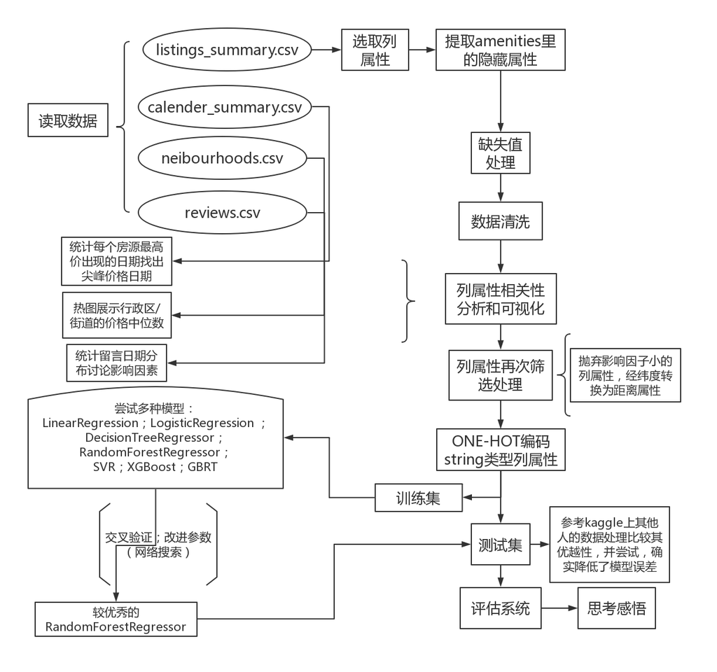

```python
#请确保已安装以下库
import numpy as np
import pandas as pd
import matplotlib.pyplot as plt
from sklearn.linear_model import LinearRegression
from sklearn.ensemble import RandomForestRegressor
from sklearn.svm import SVR
import xgboost as xgb
from sklearn.ensemble import GradientBoostingRegressor
from sklearn.metrics import mean_squared_error
from sklearn.model_selection import cross_val_score
from sklearn.model_selection import RandomizedSearchCV
from sklearn.model_selection import GridSearchCV
from scipy.stats import randint
from geopy.distance import great_circle
import os
```

# 读取数据

> 把下方路径替换为csv文件所在路径即可

```python
def loaddata(name):
    csv_path='C:\\Users\\LENOVO\\' + name
    return pd.read_csv(csv_path)
```

```python
listings=loaddata('listings(Summary information and metrics for listings in Berlin).csv')
listings_summary=loaddata('listings_summary(Detailed Listings Data for Berlin).csv')
calendar_summary=loaddata('calendar_summary(Detailed Calendar Data for listings in Berlin.).csv')
neighbourhoods=loaddata('neighbourhoods(Neighbourhood list for geo filter).csv')
reviews=loaddata('reviews(Detailed Review Data for listings in Berlin).csv')
```

#### listings_summary是listings的完整版，所以直接看listings_summary看看有没有和价格相关的属性。

```python
listings_summary.head(1)
```

|  | id | listing_url | scrape_id | last_scraped | name | summary | space | description | experiences_offered | neighborhood_overview | ... | requires_license | license | jurisdiction_names | instant_bookable | is_business_travel_ready | cancellation_policy | require_guest_profile_picture | require_guest_phone_verification | calculated_host_listings_count | reviews_per_month |
| --- | --- | --- | --- | --- | --- | --- | --- | --- | --- | --- | --- | --- | --- | --- | --- | --- | --- | --- | --- | --- | --- |
| 0 | 2015 | https://www.airbnb.com/rooms/2015 | 20181107122246 | 2018-11-07 | Berlin-Mitte Value! Quiet courtyard/very central | Great location! 30 of 75 sq meters. This wood... | A+++ location! This „Einliegerwohnung“ is an e... | Great location! 30 of 75 sq meters. This wood... | none | It is located in the former East Berlin area o... | ... | t | NaN | NaN | f | f | strict_14_with_grace_period | f | f | 4 | 3.76 |

1 rows × 96 columns

#### 属性名列出来

```python
listings_summary.columns
```

```
Index(['id', 'listing_url', 'scrape_id', 'last_scraped', 'name', 'summary',
       'space', 'description', 'experiences_offered', 'neighborhood_overview',
       'notes', 'transit', 'access', 'interaction', 'house_rules',
       'thumbnail_url', 'medium_url', 'picture_url', 'xl_picture_url',
       'host_id', 'host_url', 'host_name', 'host_since', 'host_location',
       'host_about', 'host_response_time', 'host_response_rate',
       'host_acceptance_rate', 'host_is_superhost', 'host_thumbnail_url',
       'host_picture_url', 'host_neighbourhood', 'host_listings_count',
       'host_total_listings_count', 'host_verifications',
       'host_has_profile_pic', 'host_identity_verified', 'street',
       'neighbourhood', 'neighbourhood_cleansed',
       'neighbourhood_group_cleansed', 'city', 'state', 'zipcode', 'market',
       'smart_location', 'country_code', 'country', 'latitude', 'longitude',
       'is_location_exact', 'property_type', 'room_type', 'accommodates',
       'bathrooms', 'bedrooms', 'beds', 'bed_type', 'amenities', 'square_feet',
       'price', 'weekly_price', 'monthly_price', 'security_deposit',
       'cleaning_fee', 'guests_included', 'extra_people', 'minimum_nights',
       'maximum_nights', 'calendar_updated', 'has_availability',
       'availability_30', 'availability_60', 'availability_90',
       'availability_365', 'calendar_last_scraped', 'number_of_reviews',
       'first_review', 'last_review', 'review_scores_rating',
       'review_scores_accuracy', 'review_scores_cleanliness',
       'review_scores_checkin', 'review_scores_communication',
       'review_scores_location', 'review_scores_value', 'requires_license',
       'license', 'jurisdiction_names', 'instant_bookable',
       'is_business_travel_ready', 'cancellation_policy',
       'require_guest_profile_picture', 'require_guest_phone_verification',
       'calculated_host_listings_count', 'reviews_per_month'],
      dtype='object')
```

# 数据选取

#### 非常之多，有96个属性，很多含义必须结合网页内容理解例如：https://www.airbnb.com/rooms/2015 ，以下属性我就以此网页为例分析。

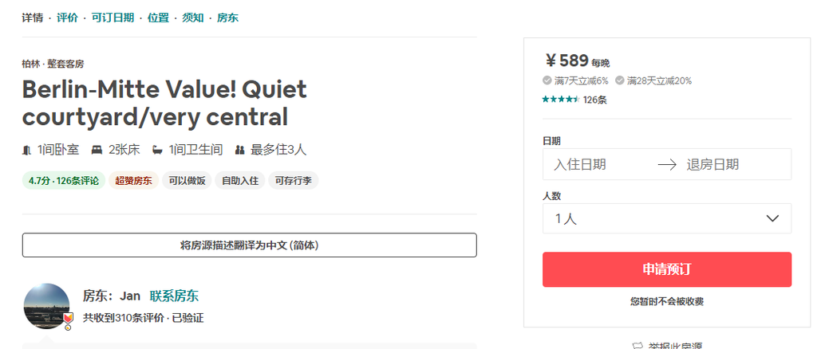

#### 首先不考虑无关属性如url等，以及大量文字描述的属性，例如space，description等，我还没有能力处理这些自然语言。

#### 最后我凭着自身经验选取了这些：

> 1. price 预测的目标数值。
> 2. id，作为每行的索引，因为和其他文件的排序不一致，所以要用id作为识别索引。
> 3. accommodates，‘最多住3人’之类的，当然影响价格。
> 4. bedrooms，‘1间卧室’之类。
> 5. bathrooms，‘1间卫生间’之类。
> 6. beds，‘2张床’之类。
> 7. room_type,Private room/Entire home之类。
> 8. bed_type，real床，或者sofa作床（哈哈）。
> 9. property_type，公寓等类型。
> 10. cleaning_fee,清理价格。
> 11. security_deposit，押金。
> 12. extra_people，不知道啥意思，但是内容是金额，估计有关系。
> 13. guests_included,不知道啥意思，大概是已经有的住客？内容是多是1-4整数，估计有关系。
> 14. host_has_profile_pic, 是否上传了照片，用t表示有，属于二值变量，有关。
> 15. latitude, longitude, 经纬度，当然，一会也可以画个图看看。
> 16. minimum_nights，最短天数。
> 17. instant_bookable，及时预订？二值变量，用t/f表示。
> 18. is_business_travel_ready,商务旅游，t/f表示。
> 19. cancellation_policy, 取消预订的政策，有flexible，moderate等不多的string类别。
> 20. amenities，设施，虽然是杂乱的描述，但是对价格很重要，我打算先做个统计，提取关键词转换成多个参数，TV，WIFI等。
> 21. 'neighbourhood','neighbourhood_group_cleansed','neighbourhood_cleansed' 这几个表示街区的我不太清楚有什么现实意义，先放着。

```python
temp_col = [ 'id','price','accommodates', 'bathrooms','beds', 'bedrooms', 'room_type', 'bed_type','property_type', 'cleaning_fee',
          'security_deposit','extra_people', 'guests_included', 'host_has_profile_pic','latitude', 'longitude',
          'minimum_nights', 'instant_bookable', 'is_business_travel_ready','cancellation_policy',
          'amenities','neighbourhood','neighbourhood_group_cleansed','neighbourhood_cleansed',]
listings_s_1 = listings_summary[temp_col]
listings_s_1
```

|  | id | price | accommodates | bathrooms | beds | bedrooms | room_type | bed_type | property_type | cleaning_fee | ... | latitude | longitude | minimum_nights | instant_bookable | is_business_travel_ready | cancellation_policy | amenities | neighbourhood | neighbourhood_group_cleansed | neighbourhood_cleansed |
| --- | --- | --- | --- | --- | --- | --- | --- | --- | --- | --- | --- | --- | --- | --- | --- | --- | --- | --- | --- | --- | --- |
| 0 | 2015 | $60.00 | 3 | 1.0 | 2.0 | 1.0 | Entire home/apt | Real Bed | Guesthouse | $30.00 | ... | 52.534537 | 13.402557 | 4 | f | f | strict_14_with_grace_period | {TV,"Cable TV",Wifi,Kitchen,Gym,Heating,"Famil... | Mitte | Mitte | Brunnenstr. Süd |
| 1 | 2695 | $17.00 | 2 | 1.0 | 1.0 | 1.0 | Private room | Real Bed | Apartment | $0.00 | ... | 52.548513 | 13.404553 | 2 | f | f | flexible | {Wifi,Kitchen,Elevator,Heating,Washer,Essentia... | NaN | Pankow | Prenzlauer Berg Nordwest |
| 2 | 3176 | $90.00 | 4 | 1.0 | 2.0 | 1.0 | Entire home/apt | Real Bed | Apartment | $50.00 | ... | 52.534996 | 13.417579 | 62 | t | f | strict_14_with_grace_period | {Internet,Wifi,Kitchen,"Buzzer/wireless interc... | Prenzlauer Berg | Pankow | Prenzlauer Berg Südwest |
| 3 | 3309 | $26.00 | 2 | 1.0 | 1.0 | 1.0 | Private room | Pull-out Sofa | Apartment | $30.00 | ... | 52.498855 | 13.349065 | 5 | f | f | strict_14_with_grace_period | {Internet,Wifi,"Pets allowed","Pets live on th... | Schöneberg | Tempelhof - Schöneberg | Schöneberg-Nord |
| 4 | 7071 | $42.00 | 2 | 1.0 | 2.0 | 1.0 | Private room | Real Bed | Apartment | $0.00 | ... | 52.543157 | 13.415091 | 2 | f | f | moderate | {Wifi,Heating,"Family/kid friendly",Essentials... | Prenzlauer Berg | Pankow | Helmholtzplatz |
| 5 | 9991 | $180.00 | 7 | 2.5 | 7.0 | 4.0 | Entire home/apt | Real Bed | Apartment | $80.00 | ... | 52.533031 | 13.416047 | 6 | f | f | strict_14_with_grace_period | {TV,"Cable TV",Internet,Wifi,Kitchen,"Paid par... | Prenzlauer Berg | Pankow | Prenzlauer Berg Südwest |
| 6 | 14325 | $70.00 | 2 | 1.0 | 1.0 | 0.0 | Entire home/apt | Real Bed | Apartment | $0.00 | ... | 52.547846 | 13.405562 | 90 | f | f | strict_14_with_grace_period | {TV,Internet,Wifi,Kitchen,"Buzzer/wireless int... | Prenzlauer Berg | Pankow | Prenzlauer Berg Nordwest |
| 7 | 16401 | $120.00 | 2 | 1.0 | 2.0 | 1.0 | Private room | Real Bed | Apartment | NaN | ... | 52.510514 | 13.457850 | 30 | f | f | strict_14_with_grace_period | {TV,"Cable TV",Internet,Wifi,Kitchen,"Smoking ... | Friedrichshain | Friedrichshain-Kreuzberg | Frankfurter Allee Süd FK |
| 8 | 16644 | $90.00 | 5 | 1.0 | 3.0 | 1.0 | Entire home/apt | Real Bed | Apartment | $50.00 | ... | 52.504792 | 13.435102 | 60 | f | f | strict_14_with_grace_period | {TV,Wifi,Kitchen,"Buzzer/wireless intercom",He... | Kreuzberg | Friedrichshain-Kreuzberg | nördliche Luisenstadt |
| 9 | 17409 | $45.00 | 2 | 1.0 | 1.0 | 1.0 | Private room | Real Bed | Condominium | $18.00 | ... | 52.529071 | 13.412843 | 3 | f | f | strict_14_with_grace_period | {TV,Internet,Wifi,Kitchen,"Paid parking off pr... | Prenzlauer Berg | Pankow | Prenzlauer Berg Südwest |
| 10 | 17904 | $49.00 | 2 | 1.0 | 1.0 | NaN | Entire home/apt | Real Bed | Apartment | $50.00 | ... | 52.495476 | 13.421821 | 5 | f | f | strict_14_with_grace_period | {TV,Wifi,Kitchen,"Free street parking","Buzzer... | Neukölln | Neukölln | Reuterstraße |
| 11 | 20858 | $129.00 | 4 | 1.0 | 2.0 | 2.0 | Entire home/apt | Real Bed | Loft | $49.00 | ... | 52.536952 | 13.407615 | 3 | f | f | strict_14_with_grace_period | {TV,Wifi,Kitchen,Elevator,"Indoor fireplace",H... | Prenzlauer Berg | Pankow | Prenzlauer Berg Südwest |
| 12 | 21869 | $70.00 | 4 | 1.0 | 2.0 | 1.0 | Entire home/apt | Real Bed | Apartment | $40.00 | ... | 52.502733 | 13.434620 | 60 | f | f | strict_14_with_grace_period | {TV,Internet,Wifi,Kitchen,"Buzzer/wireless int... | Kreuzberg | Friedrichshain-Kreuzberg | nördliche Luisenstadt |
| 13 | 22415 | $98.00 | 4 | 1.0 | 2.0 | 2.0 | Entire home/apt | Real Bed | Apartment | $50.00 | ... | 52.494851 | 13.428501 | 3 | f | f | strict_14_with_grace_period | {"Cable TV",Internet,Wifi,Kitchen,"Pets allowe... | Kreuzberg | Friedrichshain-Kreuzberg | südliche Luisenstadt |
| 14 | 22677 | $160.00 | 5 | 1.0 | 4.0 | 1.0 | Entire home/apt | Real Bed | Apartment | $40.00 | ... | 52.534348 | 13.405577 | 3 | f | f | strict_14_with_grace_period | {TV,Internet,Wifi,"Wheelchair accessible",Kitc... | Mitte | Mitte | Brunnenstr. Süd |
| 15 | 23834 | $65.00 | 4 | 1.0 | 4.0 | 1.0 | Entire home/apt | Real Bed | Condominium | $50.00 | ... | 52.489714 | 13.379748 | 60 | f | f | strict_14_with_grace_period | {TV,Wifi,Kitchen,"Free street parking",Heating... | Kreuzberg | Friedrichshain-Kreuzberg | Tempelhofer Vorstadt |
| 16 | 24569 | $90.00 | 4 | 2.5 | 2.0 | 2.0 | Entire home/apt | Real Bed | Apartment | $35.00 | ... | 52.530791 | 13.418084 | 3 | f | f | strict_14_with_grace_period | {TV,"Cable TV",Internet,Wifi,"Wheelchair acces... | Prenzlauer Berg | Pankow | Prenzlauer Berg Südwest |
| 17 | 25653 | $90.00 | 4 | 2.5 | 2.0 | 2.0 | Entire home/apt | Real Bed | Apartment | $55.00 | ... | 52.530259 | 13.419467 | 4 | f | f | strict_14_with_grace_period | {TV,"Cable TV",Internet,Wifi,"Wheelchair acces... | NaN | Pankow | Prenzlauer Berg Süd |
| 18 | 26543 | $197.00 | 8 | 2.0 | 8.0 | 2.0 | Entire home/apt | Real Bed | Apartment | $50.00 | ... | 52.544062 | 13.421377 | 3 | t | f | strict_14_with_grace_period | {TV,Internet,Wifi,Kitchen,"Free street parking... | Prenzlauer Berg | Pankow | Helmholtzplatz |
| 19 | 28156 | $70.00 | 2 | 1.0 | 1.0 | 0.0 | Entire home/apt | Real Bed | Apartment | NaN | ... | 52.546719 | 13.405117 | 90 | f | f | strict_14_with_grace_period | {TV,Internet,Wifi,Kitchen,"Buzzer/wireless int... | Prenzlauer Berg | Pankow | Prenzlauer Berg Nordwest |
| 20 | 28268 | $90.00 | 6 | 1.0 | 4.0 | 2.0 | Entire home/apt | Real Bed | Apartment | $50.00 | ... | 52.513385 | 13.469948 | 5 | f | f | strict_14_with_grace_period | {TV,Internet,Wifi,Kitchen,"Free parking on pre... | Friedrichshain | Friedrichshain-Kreuzberg | Frankfurter Allee Süd FK |
| 21 | 28711 | $60.00 | 3 | NaN | NaN | 1.0 | Entire home/apt | Real Bed | Apartment | $30.00 | ... | 52.486106 | 13.434817 | 2 | f | f | flexible | {} | Neukölln | Neukölln | Reuterstraße |
| 22 | 29279 | $130.00 | 4 | 1.0 | 3.0 | 2.0 | Entire home/apt | Real Bed | Apartment | $80.00 | ... | 52.541788 | 13.423883 | 60 | f | f | strict_14_with_grace_period | {TV,Wifi,Kitchen,"Paid parking off premises",H... | Prenzlauer Berg | Pankow | Helmholtzplatz |
| 23 | 30295 | $100.00 | 8 | 1.0 | 4.0 | 2.0 | Entire home/apt | Real Bed | Apartment | $40.00 | ... | 52.545967 | 13.422359 | 4 | t | f | strict_14_with_grace_period | {TV,"Cable TV",Internet,Wifi,"Wheelchair acces... | Prenzlauer Berg | Pankow | Helmholtzplatz |
| 24 | 31440 | $44.00 | 1 | 1.0 | 1.0 | 1.0 | Private room | Real Bed | Apartment | $15.00 | ... | 52.543089 | 13.422453 | 1 | f | f | moderate | {TV,"Cable TV",Internet,Wifi,Kitchen,Heating,W... | Prenzlauer Berg | Pankow | Helmholtzplatz |
| 25 | 33043 | $62.00 | 4 | 1.0 | 2.0 | 1.0 | Entire home/apt | Real Bed | Apartment | $20.00 | ... | 52.521418 | 13.357082 | 3 | t | f | strict_14_with_grace_period | {Wifi,Kitchen,"Free street parking",Heating,"F... | Moabit | Mitte | Moabit Ost |
| 26 | 35642 | $55.00 | 2 | 1.0 | 1.0 | 1.0 | Entire home/apt | Real Bed | Apartment | $50.00 | ... | 52.549361 | 13.418228 | 60 | t | f | strict_14_with_grace_period | {TV,Wifi,Kitchen,Heating,Washer,Dryer,Microwav... | NaN | Pankow | Prenzlauer Berg Nord |
| 27 | 36480 | $40.00 | 1 | 0.0 | 1.0 | 1.0 | Private room | Real Bed | Apartment | $5.00 | ... | 52.519677 | 13.302089 | 1 | f | f | flexible | {Heating,Essentials,Hangers,"Hair dryer",Iron,... | Charlottenburg | Charlottenburg-Wilm. | Otto-Suhr-Allee |
| 28 | 37004 | $25.00 | 1 | 1.0 | 1.0 | 1.0 | Private room | Real Bed | Apartment | $0.00 | ... | 52.493389 | 13.364813 | 5 | f | f | strict_14_with_grace_period | {"Cable TV",Wifi,Kitchen,"Smoking allowed","Pe... | Schöneberg | Tempelhof - Schöneberg | Schöneberg-Nord |
| 29 | 37052 | $52.00 | 2 | 1.0 | 2.0 | 1.0 | Entire home/apt | Real Bed | Apartment | $30.00 | ... | 52.538220 | 13.404625 | 2 | f | f | strict_14_with_grace_period | {Wifi,Kitchen,Heating,"Family/kid friendly",Wa... | Mitte | Mitte | Brunnenstr. Süd |
| ... | ... | ... | ... | ... | ... | ... | ... | ... | ... | ... | ... | ... | ... | ... | ... | ... | ... | ... | ... | ... | ... |
| 22522 | 29830140 | $45.00 | 2 | 1.0 | 1.0 | 1.0 | Private room | Real Bed | Apartment | $30.00 | ... | 52.491236 | 13.330882 | 2 | t | f | moderate | {Wifi,Kitchen,"Smoking allowed",Elevator,Heati... | Wilmersdorf | Charlottenburg-Wilm. | Volkspark Wilmersdorf |
| 22523 | 29830204 | $150.00 | 2 | 1.0 | 1.0 | 0.0 | Entire home/apt | Real Bed | Apartment | $30.00 | ... | 52.513255 | 13.318309 | 7 | f | f | strict_14_with_grace_period | {TV,Wifi,Kitchen,"Free parking on premises",El... | Charlottenburg | Charlottenburg-Wilm. | Otto-Suhr-Allee |
| 22524 | 29830381 | $30.00 | 2 | 0.5 | 1.0 | 1.0 | Private room | Real Bed | Apartment | $25.00 | ... | 52.504231 | 13.420850 | 7 | f | f | strict_14_with_grace_period | {Internet,Wifi,Kitchen,"Buzzer/wireless interc... | Kreuzberg | Friedrichshain-Kreuzberg | nördliche Luisenstadt |
| 22525 | 29838765 | $30.00 | 2 | 1.0 | 1.0 | 1.0 | Entire home/apt | Real Bed | Apartment | NaN | ... | 52.440587 | 13.353266 | 1 | f | f | flexible | {TV,Wifi,Kitchen,Heating,"Smoke detector",Esse... | Lankwitz | Steglitz - Zehlendorf | Lankwitz |
| 22526 | 29840432 | $599.00 | 4 | 1.0 | 2.0 | 1.0 | Private room | Real Bed | Apartment | $0.00 | ... | 52.494753 | 13.344451 | 1 | f | f | strict_14_with_grace_period | {TV,Wifi,"Air conditioning",Kitchen,"Free park... | Schöneberg | Tempelhof - Schöneberg | Schöneberg-Nord |
| 22527 | 29841234 | $399.00 | 5 | 1.0 | 1.0 | 1.0 | Private room | Real Bed | Apartment | $49.00 | ... | 52.494714 | 13.344555 | 1 | f | f | strict_14_with_grace_period | {TV,Wifi,"Air conditioning",Kitchen,"Free park... | Schöneberg | Tempelhof - Schöneberg | Schöneberg-Nord |
| 22528 | 29842909 | $100.00 | 2 | 1.0 | 1.0 | 0.0 | Entire home/apt | Real Bed | Loft | NaN | ... | 52.491119 | 13.426435 | 1 | f | f | flexible | {Wifi,Kitchen,Heating,Washer,Dryer,Essentials,... | Neukölln | Neukölln | Reuterstraße |
| 22529 | 29844866 | $35.00 | 2 | 1.0 | 1.0 | 1.0 | Private room | Real Bed | Apartment | NaN | ... | 52.484395 | 13.357489 | 1 | f | f | flexible | {Wifi,Kitchen,Heating,Washer,"Smoke detector",... | Schöneberg | Tempelhof - Schöneberg | Schöneberg-Süd |
| 22530 | 29846605 | $105.00 | 4 | 3.0 | 2.0 | 2.0 | Entire home/apt | Real Bed | Apartment | $60.00 | ... | 52.485467 | 13.438652 | 1 | f | f | flexible | {TV,Wifi,Kitchen,"Free street parking","Hot tu... | Neukölln | Neukölln | Reuterstraße |
| 22531 | 29848269 | $95.00 | 2 | 1.0 | 1.0 | 1.0 | Entire home/apt | Real Bed | Apartment | NaN | ... | 52.522064 | 13.418118 | 5 | f | f | strict_14_with_grace_period | {Wifi,Kitchen,Elevator,Heating,Washer,Essentia... | Mitte | Mitte | Alexanderplatz |
| 22532 | 29848527 | $70.00 | 2 | 1.0 | 1.0 | 0.0 | Entire home/apt | Real Bed | Loft | $299.00 | ... | 52.514998 | 13.496708 | 180 | f | f | strict_14_with_grace_period | {TV,Wifi,"Air conditioning",Kitchen,Elevator,H... | Lichtenberg | Lichtenberg | Alt-Lichtenberg |
| 22533 | 29848903 | $30.00 | 4 | 1.0 | 4.0 | 2.0 | Entire home/apt | Real Bed | Apartment | NaN | ... | 52.535236 | 13.437477 | 21 | f | f | flexible | {Wifi,Kitchen,"Pets allowed",Elevator,Heating,... | Prenzlauer Berg | Pankow | Prenzlauer Berg Ost |
| 22534 | 29848907 | $26.00 | 2 | 1.0 | 1.0 | 1.0 | Private room | Real Bed | Apartment | NaN | ... | 52.569657 | 13.420882 | 60 | f | f | strict_14_with_grace_period | {Wifi,Kitchen,Heating,Washer,"Smoke detector",... | Pankow | Pankow | Pankow Süd |
| 22535 | 29849186 | $21.00 | 1 | 1.0 | 1.0 | 1.0 | Private room | Real Bed | Apartment | NaN | ... | 52.569500 | 13.422632 | 60 | f | f | strict_14_with_grace_period | {Wifi,Kitchen,Heating,Washer,"Smoke detector",... | Pankow | Pankow | Pankow Süd |
| 22536 | 29849565 | $150.00 | 4 | 1.0 | 2.0 | 2.0 | Entire home/apt | Real Bed | Apartment | NaN | ... | 52.536666 | 13.411360 | 10 | t | f | flexible | {TV,Wifi,Kitchen,"Pets allowed",Heating,Washer... | Prenzlauer Berg | Pankow | Prenzlauer Berg Südwest |
| 22537 | 29849958 | $23.00 | 1 | 1.0 | 1.0 | 1.0 | Private room | Real Bed | Apartment | NaN | ... | 52.569261 | 13.422296 | 60 | f | f | strict_14_with_grace_period | {Wifi,Kitchen,Heating,Washer,"Smoke detector",... | Pankow | Pankow | Pankow Süd |
| 22538 | 29850404 | $60.00 | 2 | 1.0 | 1.0 | 0.0 | Private room | Real Bed | Apartment | NaN | ... | 52.496963 | 13.420962 | 1 | t | f | flexible | {Wifi,Kitchen,"Smoking allowed",Heating,Washer... | Kreuzberg | Friedrichshain-Kreuzberg | südliche Luisenstadt |
| 22539 | 29850644 | $30.00 | 1 | 1.0 | 2.0 | 0.0 | Entire home/apt | Real Bed | Apartment | NaN | ... | 52.508844 | 13.273118 | 7 | f | f | flexible | {Wifi,Kitchen,"Free parking on premises",Eleva... | Westend | Charlottenburg-Wilm. | Westend |
| 22540 | 29850727 | $30.00 | 2 | 1.0 | 1.0 | 1.0 | Entire home/apt | Real Bed | Apartment | NaN | ... | 52.497266 | 13.464208 | 1 | f | f | flexible | {Wifi,Kitchen,Heating,Washer,Essentials,Hanger... | Friedrichshain | Friedrichshain-Kreuzberg | Frankfurter Allee Süd FK |
| 22541 | 29851223 | $19.00 | 2 | 1.0 | 1.0 | 1.0 | Private room | Real Bed | Apartment | $0.00 | ... | 52.478012 | 13.448766 | 2 | t | f | flexible | {Wifi,Kitchen,"Smoking allowed",Heating,Washer... | Neukölln | Neukölln | Rixdorf |
| 22542 | 29851651 | $40.00 | 2 | 1.0 | 1.0 | 1.0 | Private room | Real Bed | Apartment | NaN | ... | 52.470724 | 13.323199 | 1 | t | f | flexible | {TV,Kitchen,Heating,Washer,"Smoke detector","F... | Friedenau | Tempelhof - Schöneberg | Friedenau |
| 22543 | 29853463 | $29.00 | 1 | 1.0 | 1.0 | 1.0 | Shared room | Real Bed | Apartment | NaN | ... | 52.469517 | 13.442539 | 2 | f | f | flexible | {Wifi,Kitchen,Heating,Washer,"Smoke detector",... | Neukölln | Neukölln | Rixdorf |
| 22544 | 29856029 | $90.00 | 4 | 1.0 | 2.0 | 2.0 | Entire home/apt | Real Bed | Apartment | $20.00 | ... | 52.515574 | 13.456987 | 2 | t | f | flexible | {Wifi,Kitchen,Elevator,Heating,Washer,"Smoke d... | Friedrichshain | Friedrichshain-Kreuzberg | Frankfurter Allee Nord |
| 22545 | 29856359 | $39.00 | 4 | 1.0 | 2.0 | 1.0 | Private room | Real Bed | Apartment | $10.00 | ... | 52.508700 | 13.445511 | 1 | t | f | moderate | {Wifi,Kitchen,Elevator,Heating,Washer,Dryer,Es... | Friedrichshain | Friedrichshain-Kreuzberg | Karl-Marx-Allee-Süd |
| 22546 | 29856646 | $100.00 | 4 | 1.0 | 2.0 | 2.0 | Entire home/apt | Real Bed | Apartment | $100.00 | ... | 52.488700 | 13.354795 | 28 | t | f | strict_14_with_grace_period | {Wifi,Kitchen,"Free parking on premises","Indo... | Schöneberg | Tempelhof - Schöneberg | Schöneberg-Süd |
| 22547 | 29856708 | $60.00 | 2 | 1.0 | 1.0 | 1.0 | Entire home/apt | Real Bed | Apartment | NaN | ... | 52.533865 | 13.400731 | 2 | f | f | flexible | {Wifi,"Smoking allowed",Heating,Essentials,Sha... | Mitte | Mitte | Brunnenstr. Süd |
| 22548 | 29857108 | $20.00 | 6 | 1.0 | 4.0 | 1.0 | Shared room | Real Bed | Apartment | $0.00 | ... | 52.496211 | 13.341738 | 1 | t | f | flexible | {TV,Wifi,Kitchen,"Free parking on premises","F... | Schöneberg | Tempelhof - Schöneberg | Schöneberg-Nord |
| 22549 | 29864272 | $85.00 | 2 | 1.0 | 1.0 | 0.0 | Entire home/apt | Real Bed | Loft | NaN | ... | 52.531800 | 13.411999 | 3 | f | f | flexible | {Wifi,Kitchen,Heating,Washer,"Fire extinguishe... | Prenzlauer Berg | Pankow | Prenzlauer Berg Südwest |
| 22550 | 29866805 | $99.00 | 2 | 1.0 | 1.0 | 1.0 | Private room | Real Bed | Boutique hotel | NaN | ... | 52.520802 | 13.378688 | 1 | f | f | flexible | {Wifi,"Paid parking off premises",Doorman,Elev... | Mitte | Mitte | Alexanderplatz |
| 22551 | 29867352 | $45.00 | 2 | 1.0 | 1.0 | 1.0 | Private room | Real Bed | Apartment | NaN | ... | 52.473762 | 13.424447 | 5 | f | f | flexible | {Wifi,"Air conditioning",Kitchen,Breakfast,Hea... | Neukölln | Neukölln | Schillerpromenade |

22552 rows × 24 columns

#### 清爽了很多，然后再把id设为索引

#### pd.set_index用法参见http://pandas.pydata.org/pandas-docs/stable/reference/api/pandas.DataFrame.set_index.html

```python
listings_s_1 = listings_s_1.set_index('id')
listings_s_1
```

| id | price | accommodates | bathrooms | beds | bedrooms | room_type | bed_type | property_type | cleaning_fee | security_deposit | ... | latitude | longitude | minimum_nights | instant_bookable | is_business_travel_ready | cancellation_policy | amenities | neighbourhood | neighbourhood_group_cleansed | neighbourhood_cleansed |
| --- | --- | --- | --- | --- | --- | --- | --- | --- | --- | --- | --- | --- | --- | --- | --- | --- | --- | --- | --- | --- | --- |
| 2015 | $60.00 | 3 | 1.0 | 2.0 | 1.0 | Entire home/apt | Real Bed | Guesthouse | $30.00 | $200.00 | ... | 52.534537 | 13.402557 | 4 | f | f | strict_14_with_grace_period | {TV,"Cable TV",Wifi,Kitchen,Gym,Heating,"Famil... | Mitte | Mitte | Brunnenstr. Süd |
| 2695 | $17.00 | 2 | 1.0 | 1.0 | 1.0 | Private room | Real Bed | Apartment | $0.00 | $0.00 | ... | 52.548513 | 13.404553 | 2 | f | f | flexible | {Wifi,Kitchen,Elevator,Heating,Washer,Essentia... | NaN | Pankow | Prenzlauer Berg Nordwest |
| 3176 | $90.00 | 4 | 1.0 | 2.0 | 1.0 | Entire home/apt | Real Bed | Apartment | $50.00 | $200.00 | ... | 52.534996 | 13.417579 | 62 | t | f | strict_14_with_grace_period | {Internet,Wifi,Kitchen,"Buzzer/wireless interc... | Prenzlauer Berg | Pankow | Prenzlauer Berg Südwest |
| 3309 | $26.00 | 2 | 1.0 | 1.0 | 1.0 | Private room | Pull-out Sofa | Apartment | $30.00 | $250.00 | ... | 52.498855 | 13.349065 | 5 | f | f | strict_14_with_grace_period | {Internet,Wifi,"Pets allowed","Pets live on th... | Schöneberg | Tempelhof - Schöneberg | Schöneberg-Nord |
| 7071 | $42.00 | 2 | 1.0 | 2.0 | 1.0 | Private room | Real Bed | Apartment | $0.00 | $0.00 | ... | 52.543157 | 13.415091 | 2 | f | f | moderate | {Wifi,Heating,"Family/kid friendly",Essentials... | Prenzlauer Berg | Pankow | Helmholtzplatz |
| 9991 | $180.00 | 7 | 2.5 | 7.0 | 4.0 | Entire home/apt | Real Bed | Apartment | $80.00 | $400.00 | ... | 52.533031 | 13.416047 | 6 | f | f | strict_14_with_grace_period | {TV,"Cable TV",Internet,Wifi,Kitchen,"Paid par... | Prenzlauer Berg | Pankow | Prenzlauer Berg Südwest |
| 14325 | $70.00 | 2 | 1.0 | 1.0 | 0.0 | Entire home/apt | Real Bed | Apartment | $0.00 | $500.00 | ... | 52.547846 | 13.405562 | 90 | f | f | strict_14_with_grace_period | {TV,Internet,Wifi,Kitchen,"Buzzer/wireless int... | Prenzlauer Berg | Pankow | Prenzlauer Berg Nordwest |
| 16401 | $120.00 | 2 | 1.0 | 2.0 | 1.0 | Private room | Real Bed | Apartment | NaN | NaN | ... | 52.510514 | 13.457850 | 30 | f | f | strict_14_with_grace_period | {TV,"Cable TV",Internet,Wifi,Kitchen,"Smoking ... | Friedrichshain | Friedrichshain-Kreuzberg | Frankfurter Allee Süd FK |
| 16644 | $90.00 | 5 | 1.0 | 3.0 | 1.0 | Entire home/apt | Real Bed | Apartment | $50.00 | $500.00 | ... | 52.504792 | 13.435102 | 60 | f | f | strict_14_with_grace_period | {TV,Wifi,Kitchen,"Buzzer/wireless intercom",He... | Kreuzberg | Friedrichshain-Kreuzberg | nördliche Luisenstadt |
| 17409 | $45.00 | 2 | 1.0 | 1.0 | 1.0 | Private room | Real Bed | Condominium | $18.00 | $0.00 | ... | 52.529071 | 13.412843 | 3 | f | f | strict_14_with_grace_period | {TV,Internet,Wifi,Kitchen,"Paid parking off pr... | Prenzlauer Berg | Pankow | Prenzlauer Berg Südwest |
| 17904 | $49.00 | 2 | 1.0 | 1.0 | NaN | Entire home/apt | Real Bed | Apartment | $50.00 | $0.00 | ... | 52.495476 | 13.421821 | 5 | f | f | strict_14_with_grace_period | {TV,Wifi,Kitchen,"Free street parking","Buzzer... | Neukölln | Neukölln | Reuterstraße |
| 20858 | $129.00 | 4 | 1.0 | 2.0 | 2.0 | Entire home/apt | Real Bed | Loft | $49.00 | $500.00 | ... | 52.536952 | 13.407615 | 3 | f | f | strict_14_with_grace_period | {TV,Wifi,Kitchen,Elevator,"Indoor fireplace",H... | Prenzlauer Berg | Pankow | Prenzlauer Berg Südwest |
| 21869 | $70.00 | 4 | 1.0 | 2.0 | 1.0 | Entire home/apt | Real Bed | Apartment | $40.00 | $500.00 | ... | 52.502733 | 13.434620 | 60 | f | f | strict_14_with_grace_period | {TV,Internet,Wifi,Kitchen,"Buzzer/wireless int... | Kreuzberg | Friedrichshain-Kreuzberg | nördliche Luisenstadt |
| 22415 | $98.00 | 4 | 1.0 | 2.0 | 2.0 | Entire home/apt | Real Bed | Apartment | $50.00 | $300.00 | ... | 52.494851 | 13.428501 | 3 | f | f | strict_14_with_grace_period | {"Cable TV",Internet,Wifi,Kitchen,"Pets allowe... | Kreuzberg | Friedrichshain-Kreuzberg | südliche Luisenstadt |
| 22677 | $160.00 | 5 | 1.0 | 4.0 | 1.0 | Entire home/apt | Real Bed | Apartment | $40.00 | $150.00 | ... | 52.534348 | 13.405577 | 3 | f | f | strict_14_with_grace_period | {TV,Internet,Wifi,"Wheelchair accessible",Kitc... | Mitte | Mitte | Brunnenstr. Süd |
| 23834 | $65.00 | 4 | 1.0 | 4.0 | 1.0 | Entire home/apt | Real Bed | Condominium | $50.00 | $500.00 | ... | 52.489714 | 13.379748 | 60 | f | f | strict_14_with_grace_period | {TV,Wifi,Kitchen,"Free street parking",Heating... | Kreuzberg | Friedrichshain-Kreuzberg | Tempelhofer Vorstadt |
| 24569 | $90.00 | 4 | 2.5 | 2.0 | 2.0 | Entire home/apt | Real Bed | Apartment | $35.00 | $200.00 | ... | 52.530791 | 13.418084 | 3 | f | f | strict_14_with_grace_period | {TV,"Cable TV",Internet,Wifi,"Wheelchair acces... | Prenzlauer Berg | Pankow | Prenzlauer Berg Südwest |
| 25653 | $90.00 | 4 | 2.5 | 2.0 | 2.0 | Entire home/apt | Real Bed | Apartment | $55.00 | $200.00 | ... | 52.530259 | 13.419467 | 4 | f | f | strict_14_with_grace_period | {TV,"Cable TV",Internet,Wifi,"Wheelchair acces... | NaN | Pankow | Prenzlauer Berg Süd |
| 26543 | $197.00 | 8 | 2.0 | 8.0 | 2.0 | Entire home/apt | Real Bed | Apartment | $50.00 | $250.00 | ... | 52.544062 | 13.421377 | 3 | t | f | strict_14_with_grace_period | {TV,Internet,Wifi,Kitchen,"Free street parking... | Prenzlauer Berg | Pankow | Helmholtzplatz |
| 28156 | $70.00 | 2 | 1.0 | 1.0 | 0.0 | Entire home/apt | Real Bed | Apartment | NaN | $1,660.00 | ... | 52.546719 | 13.405117 | 90 | f | f | strict_14_with_grace_period | {TV,Internet,Wifi,Kitchen,"Buzzer/wireless int... | Prenzlauer Berg | Pankow | Prenzlauer Berg Nordwest |
| 28268 | $90.00 | 6 | 1.0 | 4.0 | 2.0 | Entire home/apt | Real Bed | Apartment | $50.00 | $200.00 | ... | 52.513385 | 13.469948 | 5 | f | f | strict_14_with_grace_period | {TV,Internet,Wifi,Kitchen,"Free parking on pre... | Friedrichshain | Friedrichshain-Kreuzberg | Frankfurter Allee Süd FK |
| 28711 | $60.00 | 3 | NaN | NaN | 1.0 | Entire home/apt | Real Bed | Apartment | $30.00 | NaN | ... | 52.486106 | 13.434817 | 2 | f | f | flexible | {} | Neukölln | Neukölln | Reuterstraße |
| 29279 | $130.00 | 4 | 1.0 | 3.0 | 2.0 | Entire home/apt | Real Bed | Apartment | $80.00 | $1,500.00 | ... | 52.541788 | 13.423883 | 60 | f | f | strict_14_with_grace_period | {TV,Wifi,Kitchen,"Paid parking off premises",H... | Prenzlauer Berg | Pankow | Helmholtzplatz |
| 30295 | $100.00 | 8 | 1.0 | 4.0 | 2.0 | Entire home/apt | Real Bed | Apartment | $40.00 | NaN | ... | 52.545967 | 13.422359 | 4 | t | f | strict_14_with_grace_period | {TV,"Cable TV",Internet,Wifi,"Wheelchair acces... | Prenzlauer Berg | Pankow | Helmholtzplatz |
| 31440 | $44.00 | 1 | 1.0 | 1.0 | 1.0 | Private room | Real Bed | Apartment | $15.00 | $100.00 | ... | 52.543089 | 13.422453 | 1 | f | f | moderate | {TV,"Cable TV",Internet,Wifi,Kitchen,Heating,W... | Prenzlauer Berg | Pankow | Helmholtzplatz |
| 33043 | $62.00 | 4 | 1.0 | 2.0 | 1.0 | Entire home/apt | Real Bed | Apartment | $20.00 | $0.00 | ... | 52.521418 | 13.357082 | 3 | t | f | strict_14_with_grace_period | {Wifi,Kitchen,"Free street parking",Heating,"F... | Moabit | Mitte | Moabit Ost |
| 35642 | $55.00 | 2 | 1.0 | 1.0 | 1.0 | Entire home/apt | Real Bed | Apartment | $50.00 | $1,000.00 | ... | 52.549361 | 13.418228 | 60 | t | f | strict_14_with_grace_period | {TV,Wifi,Kitchen,Heating,Washer,Dryer,Microwav... | NaN | Pankow | Prenzlauer Berg Nord |
| 36480 | $40.00 | 1 | 0.0 | 1.0 | 1.0 | Private room | Real Bed | Apartment | $5.00 | $500.00 | ... | 52.519677 | 13.302089 | 1 | f | f | flexible | {Heating,Essentials,Hangers,"Hair dryer",Iron,... | Charlottenburg | Charlottenburg-Wilm. | Otto-Suhr-Allee |
| 37004 | $25.00 | 1 | 1.0 | 1.0 | 1.0 | Private room | Real Bed | Apartment | $0.00 | $0.00 | ... | 52.493389 | 13.364813 | 5 | f | f | strict_14_with_grace_period | {"Cable TV",Wifi,Kitchen,"Smoking allowed","Pe... | Schöneberg | Tempelhof - Schöneberg | Schöneberg-Nord |
| 37052 | $52.00 | 2 | 1.0 | 2.0 | 1.0 | Entire home/apt | Real Bed | Apartment | $30.00 | $100.00 | ... | 52.538220 | 13.404625 | 2 | f | f | strict_14_with_grace_period | {Wifi,Kitchen,Heating,"Family/kid friendly",Wa... | Mitte | Mitte | Brunnenstr. Süd |
| ... | ... | ... | ... | ... | ... | ... | ... | ... | ... | ... | ... | ... | ... | ... | ... | ... | ... | ... | ... | ... | ... |
| 29830140 | $45.00 | 2 | 1.0 | 1.0 | 1.0 | Private room | Real Bed | Apartment | $30.00 | $0.00 | ... | 52.491236 | 13.330882 | 2 | t | f | moderate | {Wifi,Kitchen,"Smoking allowed",Elevator,Heati... | Wilmersdorf | Charlottenburg-Wilm. | Volkspark Wilmersdorf |
| 29830204 | $150.00 | 2 | 1.0 | 1.0 | 0.0 | Entire home/apt | Real Bed | Apartment | $30.00 | $150.00 | ... | 52.513255 | 13.318309 | 7 | f | f | strict_14_with_grace_period | {TV,Wifi,Kitchen,"Free parking on premises",El... | Charlottenburg | Charlottenburg-Wilm. | Otto-Suhr-Allee |
| 29830381 | $30.00 | 2 | 0.5 | 1.0 | 1.0 | Private room | Real Bed | Apartment | $25.00 | $200.00 | ... | 52.504231 | 13.420850 | 7 | f | f | strict_14_with_grace_period | {Internet,Wifi,Kitchen,"Buzzer/wireless interc... | Kreuzberg | Friedrichshain-Kreuzberg | nördliche Luisenstadt |
| 29838765 | $30.00 | 2 | 1.0 | 1.0 | 1.0 | Entire home/apt | Real Bed | Apartment | NaN | NaN | ... | 52.440587 | 13.353266 | 1 | f | f | flexible | {TV,Wifi,Kitchen,Heating,"Smoke detector",Esse... | Lankwitz | Steglitz - Zehlendorf | Lankwitz |
| 29840432 | $599.00 | 4 | 1.0 | 2.0 | 1.0 | Private room | Real Bed | Apartment | $0.00 | $0.00 | ... | 52.494753 | 13.344451 | 1 | f | f | strict_14_with_grace_period | {TV,Wifi,"Air conditioning",Kitchen,"Free park... | Schöneberg | Tempelhof - Schöneberg | Schöneberg-Nord |
| 29841234 | $399.00 | 5 | 1.0 | 1.0 | 1.0 | Private room | Real Bed | Apartment | $49.00 | $0.00 | ... | 52.494714 | 13.344555 | 1 | f | f | strict_14_with_grace_period | {TV,Wifi,"Air conditioning",Kitchen,"Free park... | Schöneberg | Tempelhof - Schöneberg | Schöneberg-Nord |
| 29842909 | $100.00 | 2 | 1.0 | 1.0 | 0.0 | Entire home/apt | Real Bed | Loft | NaN | NaN | ... | 52.491119 | 13.426435 | 1 | f | f | flexible | {Wifi,Kitchen,Heating,Washer,Dryer,Essentials,... | Neukölln | Neukölln | Reuterstraße |
| 29844866 | $35.00 | 2 | 1.0 | 1.0 | 1.0 | Private room | Real Bed | Apartment | NaN | NaN | ... | 52.484395 | 13.357489 | 1 | f | f | flexible | {Wifi,Kitchen,Heating,Washer,"Smoke detector",... | Schöneberg | Tempelhof - Schöneberg | Schöneberg-Süd |
| 29846605 | $105.00 | 4 | 3.0 | 2.0 | 2.0 | Entire home/apt | Real Bed | Apartment | $60.00 | $0.00 | ... | 52.485467 | 13.438652 | 1 | f | f | flexible | {TV,Wifi,Kitchen,"Free street parking","Hot tu... | Neukölln | Neukölln | Reuterstraße |
| 29848269 | $95.00 | 2 | 1.0 | 1.0 | 1.0 | Entire home/apt | Real Bed | Apartment | NaN | NaN | ... | 52.522064 | 13.418118 | 5 | f | f | strict_14_with_grace_period | {Wifi,Kitchen,Elevator,Heating,Washer,Essentia... | Mitte | Mitte | Alexanderplatz |
| 29848527 | $70.00 | 2 | 1.0 | 1.0 | 0.0 | Entire home/apt | Real Bed | Loft | $299.00 | $2,000.00 | ... | 52.514998 | 13.496708 | 180 | f | f | strict_14_with_grace_period | {TV,Wifi,"Air conditioning",Kitchen,Elevator,H... | Lichtenberg | Lichtenberg | Alt-Lichtenberg |
| 29848903 | $30.00 | 4 | 1.0 | 4.0 | 2.0 | Entire home/apt | Real Bed | Apartment | NaN | NaN | ... | 52.535236 | 13.437477 | 21 | f | f | flexible | {Wifi,Kitchen,"Pets allowed",Elevator,Heating,... | Prenzlauer Berg | Pankow | Prenzlauer Berg Ost |
| 29848907 | $26.00 | 2 | 1.0 | 1.0 | 1.0 | Private room | Real Bed | Apartment | NaN | NaN | ... | 52.569657 | 13.420882 | 60 | f | f | strict_14_with_grace_period | {Wifi,Kitchen,Heating,Washer,"Smoke detector",... | Pankow | Pankow | Pankow Süd |
| 29849186 | $21.00 | 1 | 1.0 | 1.0 | 1.0 | Private room | Real Bed | Apartment | NaN | NaN | ... | 52.569500 | 13.422632 | 60 | f | f | strict_14_with_grace_period | {Wifi,Kitchen,Heating,Washer,"Smoke detector",... | Pankow | Pankow | Pankow Süd |
| 29849565 | $150.00 | 4 | 1.0 | 2.0 | 2.0 | Entire home/apt | Real Bed | Apartment | NaN | NaN | ... | 52.536666 | 13.411360 | 10 | t | f | flexible | {TV,Wifi,Kitchen,"Pets allowed",Heating,Washer... | Prenzlauer Berg | Pankow | Prenzlauer Berg Südwest |
| 29849958 | $23.00 | 1 | 1.0 | 1.0 | 1.0 | Private room | Real Bed | Apartment | NaN | NaN | ... | 52.569261 | 13.422296 | 60 | f | f | strict_14_with_grace_period | {Wifi,Kitchen,Heating,Washer,"Smoke detector",... | Pankow | Pankow | Pankow Süd |
| 29850404 | $60.00 | 2 | 1.0 | 1.0 | 0.0 | Private room | Real Bed | Apartment | NaN | NaN | ... | 52.496963 | 13.420962 | 1 | t | f | flexible | {Wifi,Kitchen,"Smoking allowed",Heating,Washer... | Kreuzberg | Friedrichshain-Kreuzberg | südliche Luisenstadt |
| 29850644 | $30.00 | 1 | 1.0 | 2.0 | 0.0 | Entire home/apt | Real Bed | Apartment | NaN | NaN | ... | 52.508844 | 13.273118 | 7 | f | f | flexible | {Wifi,Kitchen,"Free parking on premises",Eleva... | Westend | Charlottenburg-Wilm. | Westend |
| 29850727 | $30.00 | 2 | 1.0 | 1.0 | 1.0 | Entire home/apt | Real Bed | Apartment | NaN | NaN | ... | 52.497266 | 13.464208 | 1 | f | f | flexible | {Wifi,Kitchen,Heating,Washer,Essentials,Hanger... | Friedrichshain | Friedrichshain-Kreuzberg | Frankfurter Allee Süd FK |
| 29851223 | $19.00 | 2 | 1.0 | 1.0 | 1.0 | Private room | Real Bed | Apartment | $0.00 | $0.00 | ... | 52.478012 | 13.448766 | 2 | t | f | flexible | {Wifi,Kitchen,"Smoking allowed",Heating,Washer... | Neukölln | Neukölln | Rixdorf |
| 29851651 | $40.00 | 2 | 1.0 | 1.0 | 1.0 | Private room | Real Bed | Apartment | NaN | NaN | ... | 52.470724 | 13.323199 | 1 | t | f | flexible | {TV,Kitchen,Heating,Washer,"Smoke detector","F... | Friedenau | Tempelhof - Schöneberg | Friedenau |
| 29853463 | $29.00 | 1 | 1.0 | 1.0 | 1.0 | Shared room | Real Bed | Apartment | NaN | NaN | ... | 52.469517 | 13.442539 | 2 | f | f | flexible | {Wifi,Kitchen,Heating,Washer,"Smoke detector",... | Neukölln | Neukölln | Rixdorf |
| 29856029 | $90.00 | 4 | 1.0 | 2.0 | 2.0 | Entire home/apt | Real Bed | Apartment | $20.00 | $100.00 | ... | 52.515574 | 13.456987 | 2 | t | f | flexible | {Wifi,Kitchen,Elevator,Heating,Washer,"Smoke d... | Friedrichshain | Friedrichshain-Kreuzberg | Frankfurter Allee Nord |
| 29856359 | $39.00 | 4 | 1.0 | 2.0 | 1.0 | Private room | Real Bed | Apartment | $10.00 | $0.00 | ... | 52.508700 | 13.445511 | 1 | t | f | moderate | {Wifi,Kitchen,Elevator,Heating,Washer,Dryer,Es... | Friedrichshain | Friedrichshain-Kreuzberg | Karl-Marx-Allee-Süd |
| 29856646 | $100.00 | 4 | 1.0 | 2.0 | 2.0 | Entire home/apt | Real Bed | Apartment | $100.00 | $1,000.00 | ... | 52.488700 | 13.354795 | 28 | t | f | strict_14_with_grace_period | {Wifi,Kitchen,"Free parking on premises","Indo... | Schöneberg | Tempelhof - Schöneberg | Schöneberg-Süd |
| 29856708 | $60.00 | 2 | 1.0 | 1.0 | 1.0 | Entire home/apt | Real Bed | Apartment | NaN | NaN | ... | 52.533865 | 13.400731 | 2 | f | f | flexible | {Wifi,"Smoking allowed",Heating,Essentials,Sha... | Mitte | Mitte | Brunnenstr. Süd |
| 29857108 | $20.00 | 6 | 1.0 | 4.0 | 1.0 | Shared room | Real Bed | Apartment | $0.00 | $0.00 | ... | 52.496211 | 13.341738 | 1 | t | f | flexible | {TV,Wifi,Kitchen,"Free parking on premises","F... | Schöneberg | Tempelhof - Schöneberg | Schöneberg-Nord |
| 29864272 | $85.00 | 2 | 1.0 | 1.0 | 0.0 | Entire home/apt | Real Bed | Loft | NaN | NaN | ... | 52.531800 | 13.411999 | 3 | f | f | flexible | {Wifi,Kitchen,Heating,Washer,"Fire extinguishe... | Prenzlauer Berg | Pankow | Prenzlauer Berg Südwest |
| 29866805 | $99.00 | 2 | 1.0 | 1.0 | 1.0 | Private room | Real Bed | Boutique hotel | NaN | NaN | ... | 52.520802 | 13.378688 | 1 | f | f | flexible | {Wifi,"Paid parking off premises",Doorman,Elev... | Mitte | Mitte | Alexanderplatz |
| 29867352 | $45.00 | 2 | 1.0 | 1.0 | 1.0 | Private room | Real Bed | Apartment | NaN | NaN | ... | 52.473762 | 13.424447 | 5 | f | f | flexible | {Wifi,"Air conditioning",Kitchen,Breakfast,Hea... | Neukölln | Neukölln | Schillerpromenade |

22552 rows × 23 columns

## 提取amenities内容

#### 观察发现amenities属性里的string格式很统一可以去掉无关char然后做统计,这里要用到计数器类型，参考https://docs.python.org/2/library/collections.html?highlight=counter 思路为，把amenities中多余char扔掉后合并所有行的string，查看出现最多的substring.因为后面还要用原来的amenities，处理后的保存为amenities2.

```python
listings_s_1['amenities2']=listings_s_1['amenities'].str.replace('}','').str.replace('{','').str.replace('"', '')
listings_s_1.head(1)['amenities2']
```

```
id
2015    TV,Cable TV,Wifi,Kitchen,Gym,Heating,Family/ki...
Name: amenities2, dtype: object
```

#### listings_s_1的每一行还只是string，要把一个string切成substring的列表。用split函数，分割切割string，参见https://docs.python.org/2/library/stdtypes.html?highlight=split#str.split

```python
import collections
cnt = collections.Counter()
listings_s_1['amenities2']=listings_s_1['amenities2'].str.split(',')
listings_s_1.head(1)['amenities2']
```

```
id
2015    [TV, Cable TV, Wifi, Kitchen, Gym, Heating, Fa...
Name: amenities2, dtype: object
```

#### 因为listings_s_1['amenities']是一个series，不能使用计时器函数，否则会报错：“'Series' object has no attribute 'cnt'”，正确写法是要让series内的每一个列表运用于这个函数，所以使用apply。很有用的一个函数。参见 http://pandas.pydata.org/pandas-docs/stable/reference/api/pandas.DataFrame.apply.html

```python
listings_s_1['amenities2'].apply(cnt.update)
cnt.most_common(50)
```

```
[('Wifi', 21512),
 ('Kitchen', 21332),
 ('Heating', 21190),
 ('Essentials', 20329),
 ('Washer', 18497),
 ('Hair dryer', 14891),
 ('Laptop friendly workspace', 14447),
 ('Hangers', 13908),
 ('Iron', 11206),
 ('Shampoo', 10654),
 ('TV', 10134),
 ('Hot water', 9744),
 ('Family/kid friendly', 8141),
 ('Internet', 7909),
 ('Host greets you', 6663),
 ('Smoke detector', 6457),
 ('Buzzer/wireless intercom', 6116),
 ('Lock on bedroom door', 5294),
 ('Refrigerator', 5212),
 ('Free street parking', 5190),
 ('Dishes and silverware', 5082),
 ('Elevator', 4867),
 ('Bed linens', 4842),
 ('Cooking basics', 4834),
 ('Stove', 4816),
 ('Smoking allowed', 4589),
 ('Oven', 4312),
 ('translation missing: en.hosting_amenity_50', 4184),
 ('First aid kit', 4011),
 ('Cable TV', 3725),
 ('Coffee maker', 3646),
 ('Dryer', 3370),
 ('Dishwasher', 3170),
 ('translation missing: en.hosting_amenity_49', 3131),
 ('Long term stays allowed', 3113),
 ('Pets allowed', 3105),
 ('Fire extinguisher', 3050),
 ('Luggage dropoff allowed', 2833),
 ('Private entrance', 2534),
 ('Extra pillows and blankets', 2526),
 ('Patio or balcony', 2422),
 ('Step-free access', 2392),
 ('Microwave', 2267),
 ('Free parking on premises', 2138),
 ('Safety card', 2134),
 ('Paid parking off premises', 2016),
 ('Private living room', 1956),
 ('Bathtub', 1671),
 ('Carbon monoxide detector', 1519),
 ('Other', 1477)]
```

#### 提取的要素有很多，倘若都选有些过量。并且并不是出现越多越重要，我选几个我认为会很大程度影响房价的要素。

#### Wifi，Hair dryer，Laptop friendly workspace，TV，Hot water，Family/kid friendly，Internet，Host greets you，Smoking allowed

#### 然后把这些要素作为布尔值做成新的列属性,利用string里的contains函数，对series使用直接返回一个布尔值的series，参见http://pandas.pydata.org/pandas-docs/stable/reference/api/pandas.Series.str.contains.html

```python
#listings_s_1['Wifi'] = 'Wifi' in listings_s_1['amenities2']
#我一开始想用这个list的in操作但是发现有问题，可能不能直接这样带。所以就转用string的函数
listings_s_1['Wifi'] =listings_s_1['amenities'].str.contains('Wifi')
listings_s_1['Hair dryer'] = listings_s_1['amenities'].str.contains('Hair dryer')
listings_s_1['Laptop_friendly_workspace'] = listings_s_1['amenities'].str.contains('Laptop friendly workspace')
listings_s_1['TV'] = listings_s_1['amenities'].str.contains('TV')
listings_s_1['Hot water'] = listings_s_1['amenities'].str.contains('Hot water')
listings_s_1['Family/kid friendly'] = listings_s_1['amenities'].str.contains('Family/kid friendly')
listings_s_1['Internet'] = listings_s_1['amenities'].str.contains('Internet')
listings_s_1['Host greets you'] = listings_s_1['amenities'].str.contains('Host greets you')
listings_s_1['Smoking allowed'] = listings_s_1['amenities'].str.contains('Smoking allowed')
listings_s_1.head()
```

| id | price | accommodates | bathrooms | beds | bedrooms | room_type | bed_type | property_type | cleaning_fee | security_deposit | ... | amenities2 | Wifi | Hair dryer | Laptop_friendly_workspace | TV | Hot water | Family/kid friendly | Internet | Host greets you | Smoking allowed |
| --- | --- | --- | --- | --- | --- | --- | --- | --- | --- | --- | --- | --- | --- | --- | --- | --- | --- | --- | --- | --- | --- |
| 2015 | $60.00 | 3 | 1.0 | 2.0 | 1.0 | Entire home/apt | Real Bed | Guesthouse | $30.00 | $200.00 | ... | [TV, Cable TV, Wifi, Kitchen, Gym, Heating, Fa... | True | True | True | True | True | True | False | False | False |
| 2695 | $17.00 | 2 | 1.0 | 1.0 | 1.0 | Private room | Real Bed | Apartment | $0.00 | $0.00 | ... | [Wifi, Kitchen, Elevator, Heating, Washer, Ess... | True | True | True | False | False | False | False | False | False |
| 3176 | $90.00 | 4 | 1.0 | 2.0 | 1.0 | Entire home/apt | Real Bed | Apartment | $50.00 | $200.00 | ... | [Internet, Wifi, Kitchen, Buzzer/wireless inte... | True | True | True | False | False | True | True | False | False |
| 3309 | $26.00 | 2 | 1.0 | 1.0 | 1.0 | Private room | Pull-out Sofa | Apartment | $30.00 | $250.00 | ... | [Internet, Wifi, Pets allowed, Pets live on th... | True | True | True | False | True | False | True | True | False |
| 7071 | $42.00 | 2 | 1.0 | 2.0 | 1.0 | Private room | Real Bed | Apartment | $0.00 | $0.00 | ... | [Wifi, Heating, Family/kid friendly, Essential... | True | True | True | False | True | True | False | False | False |

5 rows × 33 columns

#### 完美，然后就用drop函数把amenities丢掉就行了。

```python
listings_s_1 = listings_s_1.drop(columns=['amenities', 'amenities2'])
listings_s_1
```

| id | price | accommodates | bathrooms | beds | bedrooms | room_type | bed_type | property_type | cleaning_fee | security_deposit | ... | neighbourhood_cleansed | Wifi | Hair dryer | Laptop_friendly_workspace | TV | Hot water | Family/kid friendly | Internet | Host greets you | Smoking allowed |
| --- | --- | --- | --- | --- | --- | --- | --- | --- | --- | --- | --- | --- | --- | --- | --- | --- | --- | --- | --- | --- | --- |
| 2015 | $60.00 | 3 | 1.0 | 2.0 | 1.0 | Entire home/apt | Real Bed | Guesthouse | $30.00 | $200.00 | ... | Brunnenstr. Süd | True | True | True | True | True | True | False | False | False |
| 2695 | $17.00 | 2 | 1.0 | 1.0 | 1.0 | Private room | Real Bed | Apartment | $0.00 | $0.00 | ... | Prenzlauer Berg Nordwest | True | True | True | False | False | False | False | False | False |
| 3176 | $90.00 | 4 | 1.0 | 2.0 | 1.0 | Entire home/apt | Real Bed | Apartment | $50.00 | $200.00 | ... | Prenzlauer Berg Südwest | True | True | True | False | False | True | True | False | False |
| 3309 | $26.00 | 2 | 1.0 | 1.0 | 1.0 | Private room | Pull-out Sofa | Apartment | $30.00 | $250.00 | ... | Schöneberg-Nord | True | True | True | False | True | False | True | True | False |
| 7071 | $42.00 | 2 | 1.0 | 2.0 | 1.0 | Private room | Real Bed | Apartment | $0.00 | $0.00 | ... | Helmholtzplatz | True | True | True | False | True | True | False | False | False |
| 9991 | $180.00 | 7 | 2.5 | 7.0 | 4.0 | Entire home/apt | Real Bed | Apartment | $80.00 | $400.00 | ... | Prenzlauer Berg Südwest | True | True | False | True | True | True | True | False | False |
| 14325 | $70.00 | 2 | 1.0 | 1.0 | 0.0 | Entire home/apt | Real Bed | Apartment | $0.00 | $500.00 | ... | Prenzlauer Berg Nordwest | True | False | False | True | True | False | True | True | False |
| 16401 | $120.00 | 2 | 1.0 | 2.0 | 1.0 | Private room | Real Bed | Apartment | NaN | NaN | ... | Frankfurter Allee Süd FK | True | False | False | True | False | False | True | False | True |
| 16644 | $90.00 | 5 | 1.0 | 3.0 | 1.0 | Entire home/apt | Real Bed | Apartment | $50.00 | $500.00 | ... | nördliche Luisenstadt | True | True | True | True | False | True | False | False | False |
| 17409 | $45.00 | 2 | 1.0 | 1.0 | 1.0 | Private room | Real Bed | Condominium | $18.00 | $0.00 | ... | Prenzlauer Berg Südwest | True | True | True | True | True | False | True | True | False |
| 17904 | $49.00 | 2 | 1.0 | 1.0 | NaN | Entire home/apt | Real Bed | Apartment | $50.00 | $0.00 | ... | Reuterstraße | True | True | True | True | True | False | False | False | False |
| 20858 | $129.00 | 4 | 1.0 | 2.0 | 2.0 | Entire home/apt | Real Bed | Loft | $49.00 | $500.00 | ... | Prenzlauer Berg Südwest | True | False | False | True | True | True | False | False | False |
| 21869 | $70.00 | 4 | 1.0 | 2.0 | 1.0 | Entire home/apt | Real Bed | Apartment | $40.00 | $500.00 | ... | nördliche Luisenstadt | True | True | True | True | False | True | True | False | False |
| 22415 | $98.00 | 4 | 1.0 | 2.0 | 2.0 | Entire home/apt | Real Bed | Apartment | $50.00 | $300.00 | ... | südliche Luisenstadt | True | True | True | True | True | True | True | True | False |
| 22677 | $160.00 | 5 | 1.0 | 4.0 | 1.0 | Entire home/apt | Real Bed | Apartment | $40.00 | $150.00 | ... | Brunnenstr. Süd | True | True | True | True | True | True | True | False | False |
| 23834 | $65.00 | 4 | 1.0 | 4.0 | 1.0 | Entire home/apt | Real Bed | Condominium | $50.00 | $500.00 | ... | Tempelhofer Vorstadt | True | True | True | True | True | True | False | True | False |
| 24569 | $90.00 | 4 | 2.5 | 2.0 | 2.0 | Entire home/apt | Real Bed | Apartment | $35.00 | $200.00 | ... | Prenzlauer Berg Südwest | True | False | False | True | True | False | True | False | True |
| 25653 | $90.00 | 4 | 2.5 | 2.0 | 2.0 | Entire home/apt | Real Bed | Apartment | $55.00 | $200.00 | ... | Prenzlauer Berg Süd | True | False | False | True | True | True | True | False | False |
| 26543 | $197.00 | 8 | 2.0 | 8.0 | 2.0 | Entire home/apt | Real Bed | Apartment | $50.00 | $250.00 | ... | Helmholtzplatz | True | True | True | True | True | True | True | True | False |
| 28156 | $70.00 | 2 | 1.0 | 1.0 | 0.0 | Entire home/apt | Real Bed | Apartment | NaN | $1,660.00 | ... | Prenzlauer Berg Nordwest | True | False | False | True | True | False | True | True | False |
| 28268 | $90.00 | 6 | 1.0 | 4.0 | 2.0 | Entire home/apt | Real Bed | Apartment | $50.00 | $200.00 | ... | Frankfurter Allee Süd FK | True | True | False | True | False | True | True | False | False |
| 28711 | $60.00 | 3 | NaN | NaN | 1.0 | Entire home/apt | Real Bed | Apartment | $30.00 | NaN | ... | Reuterstraße | False | False | False | False | False | False | False | False | False |
| 29279 | $130.00 | 4 | 1.0 | 3.0 | 2.0 | Entire home/apt | Real Bed | Apartment | $80.00 | $1,500.00 | ... | Helmholtzplatz | True | True | False | True | True | True | False | True | False |
| 30295 | $100.00 | 8 | 1.0 | 4.0 | 2.0 | Entire home/apt | Real Bed | Apartment | $40.00 | NaN | ... | Helmholtzplatz | True | True | True | True | True | True | True | False | False |
| 31440 | $44.00 | 1 | 1.0 | 1.0 | 1.0 | Private room | Real Bed | Apartment | $15.00 | $100.00 | ... | Helmholtzplatz | True | False | False | True | False | False | True | False | False |
| 33043 | $62.00 | 4 | 1.0 | 2.0 | 1.0 | Entire home/apt | Real Bed | Apartment | $20.00 | $0.00 | ... | Moabit Ost | True | True | True | False | True | True | False | False | False |
| 35642 | $55.00 | 2 | 1.0 | 1.0 | 1.0 | Entire home/apt | Real Bed | Apartment | $50.00 | $1,000.00 | ... | Prenzlauer Berg Nord | True | False | False | True | False | False | False | False | False |
| 36480 | $40.00 | 1 | 0.0 | 1.0 | 1.0 | Private room | Real Bed | Apartment | $5.00 | $500.00 | ... | Otto-Suhr-Allee | False | True | True | False | True | False | False | True | False |
| 37004 | $25.00 | 1 | 1.0 | 1.0 | 1.0 | Private room | Real Bed | Apartment | $0.00 | $0.00 | ... | Schöneberg-Nord | True | True | True | True | True | True | False | True | True |
| 37052 | $52.00 | 2 | 1.0 | 2.0 | 1.0 | Entire home/apt | Real Bed | Apartment | $30.00 | $100.00 | ... | Brunnenstr. Süd | True | True | True | False | True | True | False | False | False |
| ... | ... | ... | ... | ... | ... | ... | ... | ... | ... | ... | ... | ... | ... | ... | ... | ... | ... | ... | ... | ... | ... |
| 29830140 | $45.00 | 2 | 1.0 | 1.0 | 1.0 | Private room | Real Bed | Apartment | $30.00 | $0.00 | ... | Volkspark Wilmersdorf | True | True | False | False | True | False | False | False | True |
| 29830204 | $150.00 | 2 | 1.0 | 1.0 | 0.0 | Entire home/apt | Real Bed | Apartment | $30.00 | $150.00 | ... | Otto-Suhr-Allee | True | True | True | True | False | False | False | False | False |
| 29830381 | $30.00 | 2 | 0.5 | 1.0 | 1.0 | Private room | Real Bed | Apartment | $25.00 | $200.00 | ... | nördliche Luisenstadt | True | False | False | False | False | True | True | False | False |
| 29838765 | $30.00 | 2 | 1.0 | 1.0 | 1.0 | Entire home/apt | Real Bed | Apartment | NaN | NaN | ... | Lankwitz | True | True | False | True | True | False | False | False | False |
| 29840432 | $599.00 | 4 | 1.0 | 2.0 | 1.0 | Private room | Real Bed | Apartment | $0.00 | $0.00 | ... | Schöneberg-Nord | True | True | True | True | False | False | False | False | True |
| 29841234 | $399.00 | 5 | 1.0 | 1.0 | 1.0 | Private room | Real Bed | Apartment | $49.00 | $0.00 | ... | Schöneberg-Nord | True | True | True | True | False | False | False | False | False |
| 29842909 | $100.00 | 2 | 1.0 | 1.0 | 0.0 | Entire home/apt | Real Bed | Loft | NaN | NaN | ... | Reuterstraße | True | False | True | False | True | False | False | False | False |
| 29844866 | $35.00 | 2 | 1.0 | 1.0 | 1.0 | Private room | Real Bed | Apartment | NaN | NaN | ... | Schöneberg-Süd | True | False | True | False | False | False | False | False | False |
| 29846605 | $105.00 | 4 | 3.0 | 2.0 | 2.0 | Entire home/apt | Real Bed | Apartment | $60.00 | $0.00 | ... | Reuterstraße | True | True | True | True | False | False | False | False | False |
| 29848269 | $95.00 | 2 | 1.0 | 1.0 | 1.0 | Entire home/apt | Real Bed | Apartment | NaN | NaN | ... | Alexanderplatz | True | False | False | False | False | False | False | False | False |
| 29848527 | $70.00 | 2 | 1.0 | 1.0 | 0.0 | Entire home/apt | Real Bed | Loft | $299.00 | $2,000.00 | ... | Alt-Lichtenberg | True | False | True | True | False | False | False | False | False |
| 29848903 | $30.00 | 4 | 1.0 | 4.0 | 2.0 | Entire home/apt | Real Bed | Apartment | NaN | NaN | ... | Prenzlauer Berg Ost | True | False | False | False | False | False | False | False | False |
| 29848907 | $26.00 | 2 | 1.0 | 1.0 | 1.0 | Private room | Real Bed | Apartment | NaN | NaN | ... | Pankow Süd | True | False | True | False | True | False | False | False | False |
| 29849186 | $21.00 | 1 | 1.0 | 1.0 | 1.0 | Private room | Real Bed | Apartment | NaN | NaN | ... | Pankow Süd | True | False | True | False | True | False | False | False | False |
| 29849565 | $150.00 | 4 | 1.0 | 2.0 | 2.0 | Entire home/apt | Real Bed | Apartment | NaN | NaN | ... | Prenzlauer Berg Südwest | True | False | True | True | False | False | False | False | False |
| 29849958 | $23.00 | 1 | 1.0 | 1.0 | 1.0 | Private room | Real Bed | Apartment | NaN | NaN | ... | Pankow Süd | True | False | True | False | True | False | False | False | False |
| 29850404 | $60.00 | 2 | 1.0 | 1.0 | 0.0 | Private room | Real Bed | Apartment | NaN | NaN | ... | südliche Luisenstadt | True | True | True | False | True | False | False | False | True |
| 29850644 | $30.00 | 1 | 1.0 | 2.0 | 0.0 | Entire home/apt | Real Bed | Apartment | NaN | NaN | ... | Westend | True | False | True | False | True | False | False | False | False |
| 29850727 | $30.00 | 2 | 1.0 | 1.0 | 1.0 | Entire home/apt | Real Bed | Apartment | NaN | NaN | ... | Frankfurter Allee Süd FK | True | True | False | False | False | False | False | False | False |
| 29851223 | $19.00 | 2 | 1.0 | 1.0 | 1.0 | Private room | Real Bed | Apartment | $0.00 | $0.00 | ... | Rixdorf | True | True | True | False | True | False | False | False | True |
| 29851651 | $40.00 | 2 | 1.0 | 1.0 | 1.0 | Private room | Real Bed | Apartment | NaN | NaN | ... | Friedenau | False | False | True | True | True | False | False | False | False |
| 29853463 | $29.00 | 1 | 1.0 | 1.0 | 1.0 | Shared room | Real Bed | Apartment | NaN | NaN | ... | Rixdorf | True | True | True | False | False | False | False | False | False |
| 29856029 | $90.00 | 4 | 1.0 | 2.0 | 2.0 | Entire home/apt | Real Bed | Apartment | $20.00 | $100.00 | ... | Frankfurter Allee Nord | True | True | True | False | False | False | False | False | False |
| 29856359 | $39.00 | 4 | 1.0 | 2.0 | 1.0 | Private room | Real Bed | Apartment | $10.00 | $0.00 | ... | Karl-Marx-Allee-Süd | True | True | True | False | False | False | False | False | False |
| 29856646 | $100.00 | 4 | 1.0 | 2.0 | 2.0 | Entire home/apt | Real Bed | Apartment | $100.00 | $1,000.00 | ... | Schöneberg-Süd | True | True | True | False | True | False | False | True | False |
| 29856708 | $60.00 | 2 | 1.0 | 1.0 | 1.0 | Entire home/apt | Real Bed | Apartment | NaN | NaN | ... | Brunnenstr. Süd | True | True | True | False | False | False | False | False | True |
| 29857108 | $20.00 | 6 | 1.0 | 4.0 | 1.0 | Shared room | Real Bed | Apartment | $0.00 | $0.00 | ... | Schöneberg-Nord | True | True | True | True | True | False | False | False | False |
| 29864272 | $85.00 | 2 | 1.0 | 1.0 | 0.0 | Entire home/apt | Real Bed | Loft | NaN | NaN | ... | Prenzlauer Berg Südwest | True | False | False | False | True | False | False | False | False |
| 29866805 | $99.00 | 2 | 1.0 | 1.0 | 1.0 | Private room | Real Bed | Boutique hotel | NaN | NaN | ... | Alexanderplatz | True | True | True | False | True | True | False | False | False |
| 29867352 | $45.00 | 2 | 1.0 | 1.0 | 1.0 | Private room | Real Bed | Apartment | NaN | NaN | ... | Schillerpromenade | True | True | True | False | False | False | False | False | False |

22552 rows × 31 columns

# 数据缺失处理

#### 先用isna函数转换成布尔framedata，参见 http://pandas.pydata.org/pandas-docs/stable/reference/api/pandas.DataFrame.isna.html#pandas.DataFrame.isna 再用sum看缺失数量。也可以用info看，都可。

```python
listings_s_1.info()
#listings_s_1.isna().sum()
```

```
<class 'pandas.core.frame.DataFrame'>
Int64Index: 22552 entries, 2015 to 29867352
Data columns (total 31 columns):
price                           22552 non-null object
accommodates                    22552 non-null int64
bathrooms                       22520 non-null float64
beds                            22512 non-null float64
bedrooms                        22534 non-null float64
room_type                       22552 non-null object
bed_type                        22552 non-null object
property_type                   22552 non-null object
cleaning_fee                    15406 non-null object
security_deposit                13191 non-null object
extra_people                    22552 non-null object
guests_included                 22552 non-null int64
host_has_profile_pic            22526 non-null object
latitude                        22552 non-null float64
longitude                       22552 non-null float64
minimum_nights                  22552 non-null int64
instant_bookable                22552 non-null object
is_business_travel_ready        22552 non-null object
cancellation_policy             22552 non-null object
neighbourhood                   21421 non-null object
neighbourhood_group_cleansed    22552 non-null object
neighbourhood_cleansed          22552 non-null object
Wifi                            22552 non-null bool
Hair dryer                      22552 non-null bool
Laptop_friendly_workspace       22552 non-null bool
TV                              22552 non-null bool
Hot water                       22552 non-null bool
Family/kid friendly             22552 non-null bool
Internet                        22552 non-null bool
Host greets you                 22552 non-null bool
Smoking allowed                 22552 non-null bool
dtypes: bool(9), float64(5), int64(3), object(14)
memory usage: 4.2+ MB
```

#### 可以发现，有数据缺失的是：bathrooms,beds,bedrooms,cleaning_fee,security_deposit,host_has_profile_pic,neighbourhood

#### host_has_profile_pic 缺的比较少，可以发现它是t/f二值，t表示有图，f表示没有，自然的缺失的应该赋为f比较合理。fillna函数参见 http://pandas.pydata.org/pandas-docs/stable/reference/api/pandas.DataFrame.fillna.html#pandas.DataFrame.fillna

```python
listings_s_2=listings_s_1.fillna(value={'host_has_profile_pic':'f'})
```

#### bathrooms，beds，bedrooms,缺的比较少，直接删除缺失的行。

#### dropna函数参见 http://pandas.pydata.org/pandas-docs/stable/reference/api/pandas.DataFrame.dropna.html

```python
listings_s_2 = listings_s_2.dropna(subset=['bathrooms', 'bedrooms','beds'])
```

#### neighbourhood缺失，它和neighbourhood_cleansed，neighbourhood_group_cleansed是什么关系呢？我从csv具体内容看，neighbourhood里的关键词要么出现在neighbourhood_cleansed中，要么出现在neighbourhood_group_cleansed中，只用后两个好像就行了，所以扔掉这个属性。

```python
listings_s_2 = listings_s_2.drop(columns=['neighbourhood'])
```

#### cleaning_fee，security_deposit 缺的比较多，占近总数据的近一半，不能直接删除。从数据来源猜测，无数据的原因可能是爬取数据没有这个属性，那么作为网页信息，没有提示要交押金大概等于押金为0。同理清洁费亦然。纯属个人推理，但目前没有想出什么处理的好方法，只能全赋值为0。

```python
listings_s_2 = listings_s_2.fillna(value={'cleaning_fee':'0','security_deposit':'0'})
#注意这里还是string格式,和其他行保持一致，之后清洗数据再改类型。
```

```python
listings_s_2.info()
#listings_s_2.isna().sum()
```

```
<class 'pandas.core.frame.DataFrame'>
Int64Index: 22472 entries, 2015 to 29867352
Data columns (total 30 columns):
price                           22472 non-null object
accommodates                    22472 non-null int64
bathrooms                       22472 non-null float64
beds                            22472 non-null float64
bedrooms                        22472 non-null float64
room_type                       22472 non-null object
bed_type                        22472 non-null object
property_type                   22472 non-null object
cleaning_fee                    22472 non-null object
security_deposit                22472 non-null object
extra_people                    22472 non-null object
guests_included                 22472 non-null int64
host_has_profile_pic            22472 non-null object
latitude                        22472 non-null float64
longitude                       22472 non-null float64
minimum_nights                  22472 non-null int64
instant_bookable                22472 non-null object
is_business_travel_ready        22472 non-null object
cancellation_policy             22472 non-null object
neighbourhood_group_cleansed    22472 non-null object
neighbourhood_cleansed          22472 non-null object
Wifi                            22472 non-null bool
Hair dryer                      22472 non-null bool
Laptop_friendly_workspace       22472 non-null bool
TV                              22472 non-null bool
Hot water                       22472 non-null bool
Family/kid friendly             22472 non-null bool
Internet                        22472 non-null bool
Host greets you                 22472 non-null bool
Smoking allowed                 22472 non-null bool
dtypes: bool(9), float64(5), int64(3), object(13)
memory usage: 4.0+ MB
```

# 数据清洗

#### 根据listings里的观察，用带美元符号的string表示价格的全部转为float格式，astype函数参见 http://pandas.pydata.org/pandas-docs/stable/reference/api/pandas.Series.astype.html?highlight=astype#pandas.Series.astype

```python
listings_s_3 = listings_s_2
listings_s_3['price'] = listings_s_3['price'].str.replace('$', '').str.replace(',', '').astype(float)
listings_s_3['cleaning_fee'] = listings_s_3['cleaning_fee'].str.replace('$', '').str.replace(',', '').astype(float)
listings_s_3['security_deposit'] = listings_s_3['security_deposit'].str.replace('$', '').str.replace(',', '').astype(float)
listings_s_3['extra_people'] = listings_s_3['extra_people'].str.replace('$', '').str.replace(',', '').astype(float)
listings_s_3.info()
```

```
<class 'pandas.core.frame.DataFrame'>
Int64Index: 22472 entries, 2015 to 29867352
Data columns (total 30 columns):
price                           22472 non-null float64
accommodates                    22472 non-null int64
bathrooms                       22472 non-null float64
beds                            22472 non-null float64
bedrooms                        22472 non-null float64
room_type                       22472 non-null object
bed_type                        22472 non-null object
property_type                   22472 non-null object
cleaning_fee                    22472 non-null float64
security_deposit                22472 non-null float64
extra_people                    22472 non-null float64
guests_included                 22472 non-null int64
host_has_profile_pic            22472 non-null object
latitude                        22472 non-null float64
longitude                       22472 non-null float64
minimum_nights                  22472 non-null int64
instant_bookable                22472 non-null object
is_business_travel_ready        22472 non-null object
cancellation_policy             22472 non-null object
neighbourhood_group_cleansed    22472 non-null object
neighbourhood_cleansed          22472 non-null object
Wifi                            22472 non-null bool
Hair dryer                      22472 non-null bool
Laptop_friendly_workspace       22472 non-null bool
TV                              22472 non-null bool
Hot water                       22472 non-null bool
Family/kid friendly             22472 non-null bool
Internet                        22472 non-null bool
Host greets you                 22472 non-null bool
Smoking allowed                 22472 non-null bool
dtypes: bool(9), float64(9), int64(3), object(9)
memory usage: 4.0+ MB
```

# 可视化与相关性分析

#### 分析各个列属性的相关性和数据分布。先看price的分布：

```python
listings_s_3['price'].describe()
```

```
count    22472.000000
mean        67.084995
std        220.576041
min          0.000000
25%         30.000000
50%         45.000000
75%         70.000000
max       9000.000000
Name: price, dtype: float64
```

#### 绝多数都在100以内，但最大值有9000，需要把这些过大的值丢掉,我通过不断画这个直方图看分布情况，最后选择450.顺便把那些无意义的为0的price行丢掉。

```python
listings_s_3.drop(listings_s_3[ (listings_s_3.price > 450) ].index, axis=0, inplace=True)
listings_s_3.drop(listings_s_3[ (listings_s_3.price == 0) ].index, axis=0, inplace=True)
```

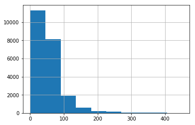

```python
listings_s_3['price'].hist()
plt.show()
```

```python
listings_s_3['price'].describe()
```

```
count    22373.000000
mean        57.707639
std         42.836970
min          1.000000
25%         30.000000
50%         45.000000
75%         70.000000
max        450.000000
Name: price, dtype: float64
```

### 再看看经纬度的图像

```
No handles with labels found to put in legend.
```

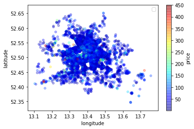

```python
listings_s_3.plot(kind="scatter",x="longitude",y="latitude",alpha=0.3,
                                 c="price",cmap=plt.get_cmap("jet"),colorbar=True,sharex=False)
plt.legend()
plt.show()
```

#### 这里发现分布呈放射状，用到中心的距离来代替经纬度也许是更好的选择，也符合距市中心距离的日常知觉。这里中心点大概是52.50,13.40，我查了下谷歌地图，以柏林这个词所写的位置为准，点了一个点获取了经纬度为52.520581，13.406881。定义一个mid_distance函数，计算距离中心距离，不能用简单的勾股定理，利用python的地理库函数可直接得到。

```python
def mid_distance(x, y):
#    return np.sqrt((52.5-x)*(52.5-x)+(13.4-y)*(13.4-y))
     return great_circle((52.520581,13.406881), (x,y)).km
```

### 造一个新的属性列，看看效果，似乎不是特别的线性相关，但是确实有影响。

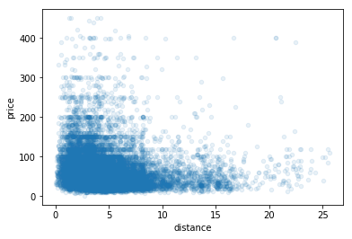

```python
listings_s_3['distance']=listings_s_3.apply(lambda x: mid_distance(x.latitude, x.longitude), axis=1)#apply真是太好用了
listings_s_3.plot(kind="scatter",x='distance',y="price",alpha=0.1)
plt.show()
```

### 丢掉经纬度

```python
listings_s_3 = listings_s_3.drop(columns=['latitude', 'longitude'])
```

### 看看各个数值对于price的相关度。

```python
corr_matrix=listings_s_3.corr()
corr_matrix["price"].sort_values(ascending=False)
```

```
price                        1.000000
accommodates                 0.573856
bedrooms                     0.473325
beds                         0.460915
guests_included              0.410070
cleaning_fee                 0.399705
TV                           0.266536
bathrooms                    0.245694
Family/kid friendly          0.231517
extra_people                 0.188777
security_deposit             0.185889
Hair dryer                   0.134016
Hot water                    0.130627
Laptop_friendly_workspace    0.083793
Internet                     0.047079
Host greets you              0.045266
minimum_nights               0.023482
Wifi                         0.013355
distance                    -0.101830
Smoking allowed             -0.147589
Name: price, dtype: float64
```

### wifi，minimum_nights很低我觉得可以扔了。另外可以看出distance成负相关正好和直观常识一致。

```python
listings_s_3 = listings_s_3.drop(columns=['Wifi', 'minimum_nights'])
```

### 我考虑把一些属性合并比如用beds/bedrooms代替这两个，但测试后的相关度并不理想，可能和bedrooms为0的情况有很大关系，所以我放弃了这种做法。

```python
# listings_s_3['beds/bedrooms'] = listings_s_3['beds']/listings_s_3['bedrooms']
# listings_s_3
```

### 接下来查看string形式的属性相关性：neighbourhood_cleansed和neighbourhood_group_cleansed

```python
listings_s_3['neighbourhood_group_cleansed'].value_counts()
```

```
Friedrichshain-Kreuzberg    5469
Mitte                       4589
Pankow                      3521
Neukölln                    3484
Charlottenburg-Wilm.        1562
Tempelhof - Schöneberg      1539
Lichtenberg                  675
Treptow - Köpenick           593
Steglitz - Zehlendorf        435
Reinickendorf                244
Marzahn - Hellersdorf        140
Spandau                      122
Name: neighbourhood_group_cleansed, dtype: int64
```

```python
listings_s_3['neighbourhood_cleansed'].value_counts()
```

```
Tempelhofer Vorstadt                  1318
Frankfurter Allee Süd FK              1275
Alexanderplatz                        1074
Reuterstraße                           996
Rixdorf                                876
Neuköllner Mitte/Zentrum               794
Brunnenstr. Süd                        765
Frankfurter Allee Nord                 731
Schillerpromenade                      660
südliche Luisenstadt                   643
Prenzlauer Berg Nordwest               621
Prenzlauer Berg Südwest                615
Schöneberg-Nord                        553
Prenzlauer Berg Süd                    550
Wedding Zentrum                        514
Moabit West                            485
nördliche Luisenstadt                  481
Schöneberg-Süd                         473
Helmholtzplatz                         452
Prenzlauer Berg Nord                   409
Südliche Friedrichstadt                388
Moabit Ost                             377
Karl-Marx-Allee-Süd                    362
Parkviertel                            354
Osloer Straße                          346
Brunnenstr. Nord                       279
Karl-Marx-Allee-Nord                   271
Tempelhof                              265
Prenzlauer Berg Ost                    241
Neu Lichtenberg                        231
                                      ...
West 3                                  13
Gropiusstadt                            12
Karow                                   12
West 5                                  12
Grünau                                  11
Buckow                                  11
Hellersdorf-Süd                         10
MV 1                                     9
Hellersdorf-Nord                         9
Falkenhagener Feld                       9
Buch                                     9
Alt-Hohenschönhausen Nord                9
Bohnsdorf                                8
Hakenfelde                               8
Siemensstadt                             8
Marienfelde                              7
Heerstraße Nord                          7
Marzahn-Mitte                            7
Köpenick-Süd                             6
Neu-Hohenschönhausen Nord                5
Müggelheim                               5
Altstadt-Kietz                           4
Kölln. Vorstadt/Spindlersf.              4
Malchow, Wartenberg und Falkenberg       3
Haselhorst                               3
Buckow Nord                              3
Allende-Viertel                          3
Neu-Hohenschönhausen Süd                 2
MV 2                                     1
Hellersdorf-Ost                          1
Name: neighbourhood_cleansed, Length: 136, dtype: int64
```

#### 对于这两者的信息我利用谷歌地图进行深入研究，发现neighbourhood_group_cleansed代表的是行政区，例如下方的Friedrichshain-Kreuzberg：

[figure not shown]

#### neighbourhood_cleansed代表着某条道路，某个广场之类的具体位置例如下方的Alexanderplatz：

[figure not shown]

#### 所以名称有很多。画一个热图看看两个变量控制下的价格中位数如何分布。有一个根据列内容分类的函数groupby 参见https://pandas.pydata.org/pandas-docs/stable/reference/api/pandas.DataFrame.groupby.html

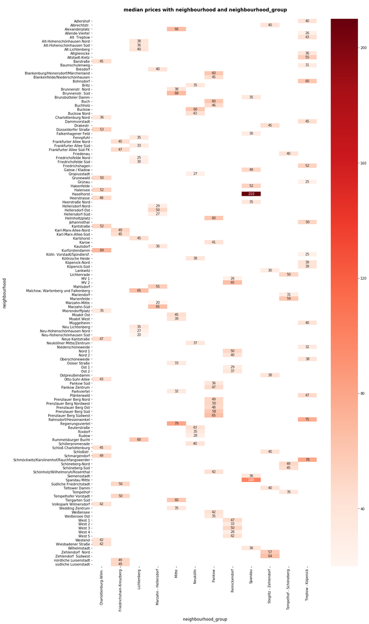

```python
import seaborn as sns
plt.figure(figsize=(15,30))
sns.heatmap(listings_s_3.groupby(['neighbourhood_cleansed','neighbourhood_group_cleansed']).price.median().unstack(),
            cmap='Reds', annot=True, fmt=".0f")

plt.xlabel('\n neighbourhood_group', fontsize=12)
plt.ylabel('neighbourhood\n', fontsize=12)
plt.title('\n median prices with neighbourhood and neighbourhood_group\n', fontsize=14, fontweight='bold');
```

### 所以这个图就是对“用社区街道预测价格”问题的回答，以上价格采用的是中位数，也可以改成平均数，随你喜欢。通过之前分析，街道和社区可能间接和distance有关来影响价格，倘若某社区明显高于另一个社区，这种差别也似乎能体现在distance上，所以再用街区展开这个属性似乎意义不大，另外倘若用one-hot编码，会带来过多的属性列。综上，我将在之后丢掉社区街道属性。

```python
listings_s_3 = listings_s_3.drop(columns=['neighbourhood_group_cleansed','neighbourhood_cleansed'])
listings_s_3.head(1)
```

| id | price | accommodates | bathrooms | beds | bedrooms | room_type | bed_type | property_type | cleaning_fee | security_deposit | ... | cancellation_policy | Hair dryer | Laptop_friendly_workspace | TV | Hot water | Family/kid friendly | Internet | Host greets you | Smoking allowed | distance |
| --- | --- | --- | --- | --- | --- | --- | --- | --- | --- | --- | --- | --- | --- | --- | --- | --- | --- | --- | --- | --- | --- |
| 2015 | 60.0 | 3 | 1.0 | 2.0 | 1.0 | Entire home/apt | Real Bed | Guesthouse | 30.0 | 200.0 | ... | strict_14_with_grace_period | True | True | True | True | True | False | False | False | 1.579203 |

1 rows × 25 columns

### 在这里顺便回答另外两个问题，可以先看一下calendar_summary.csv的具体含义，类似于机票，不同时间的房源价格也有波动，不同时间价格显示在这个csv文件里。

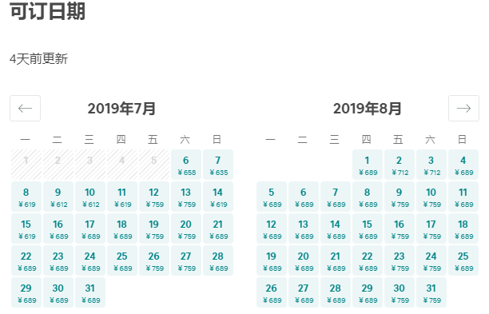

### 为简单处理，我打算统计每个房源最高价格出现的时间。同理先对这个csv进行数据清洗

```python
calendar_s_2 = calendar_summary.copy()
calendar_s_2.isna().sum()
```

```
listing_id          0
date                0
available           0
price         6430639
dtype: int64
```

```python
calendar_s_2 = calendar_s_2.dropna()
calendar_s_2['price'] = calendar_s_2['price'].str.replace('$', '').str.replace(',', '').astype(float)
calendar_s_2 = calendar_s_2.drop(calendar_s_2[calendar_s_2.price==0].index,axis=0)
calendar_s_2 = calendar_s_2.sort_values(by=['listing_id','price'],ascending=(True,False))#这里用到多列排序技巧，很实用要记住
calendar_s_2 = calendar_s_2.reset_index(drop=True)
calendar_s_2.head(10)
```

|  | listing_id | date | available | price |
| --- | --- | --- | --- | --- |
| 0 | 2015 | 2019-01-02 | t | 188.0 |
| 1 | 2015 | 2019-01-01 | t | 188.0 |
| 2 | 2015 | 2018-12-31 | t | 188.0 |
| 3 | 2015 | 2018-12-30 | t | 188.0 |
| 4 | 2015 | 2018-12-29 | t | 188.0 |
| 5 | 2015 | 2018-12-28 | t | 188.0 |
| 6 | 2015 | 2018-12-27 | t | 188.0 |
| 7 | 2015 | 2019-05-01 | t | 78.0 |
| 8 | 2015 | 2019-04-30 | t | 78.0 |
| 9 | 2015 | 2019-04-29 | t | 78.0 |

### 这里为了把每个id价格最高的几天抽取出来我费了九牛二虎之力：先是尝试遍历删除不是最高价的行，发现遍历速度极其慢，放弃遍历；之后尝试先排序，利用groupby函数合并id，挑选最大price的行，但是.max函数只能挑出一个最大值；最后终于想到了万能的apply函数，用了t.price==t.price.max()神技巧解决了这个问题！！！！！超级——不容易。apply函数真是pandas的珠宝，通过思考这个问题我的pandas理解提高了很多。

```python
calendar_s_3 = calendar_s_2.copy()
calendar_s_3 = calendar_s_3.groupby('listing_id').apply(lambda t: t[t.price==t.price.max()])
#calendar_s_3 = calendar_s_3[['listing_id','price']].groupby(by='listing_id',as_index=False).max()
calendar_s_3.head(10)
```

| listing_id |  | listing_id | date | available | price |
| --- | --- | --- | --- | --- | --- |
| 2015 | 0 | 2015 | 2019-01-02 | t | 188.0 |
|  | 1 | 2015 | 2019-01-01 | t | 188.0 |
|  | 2 | 2015 | 2018-12-31 | t | 188.0 |
|  | 3 | 2015 | 2018-12-30 | t | 188.0 |
|  | 4 | 2015 | 2018-12-29 | t | 188.0 |
|  | 5 | 2015 | 2018-12-28 | t | 188.0 |
|  | 6 | 2015 | 2018-12-27 | t | 188.0 |
| 3176 | 141 | 3176 | 2019-08-19 | t | 90.0 |
|  | 142 | 3176 | 2019-08-18 | t | 90.0 |
|  | 143 | 3176 | 2019-08-17 | t | 90.0 |

### 但这样会产生多重索引，又找到一个好用的函数index.droplevel()

参见https://pandas.pydata.org/pandas-docs/stable/reference/api/pandas.Index.droplevel.html?highlight=index%20droplevel#pandas.Index.droplevel

```python
calendar_s_3.index = calendar_s_3.index.droplevel()
calendar_s_3 = calendar_s_3.reset_index(drop=True)#为后面方便我再次重置index
calendar_s_3.head(10)
```

|  | listing_id | date | available | price |
| --- | --- | --- | --- | --- |
| 0 | 2015 | 2019-01-02 | t | 188.0 |
| 1 | 2015 | 2019-01-01 | t | 188.0 |
| 2 | 2015 | 2018-12-31 | t | 188.0 |
| 3 | 2015 | 2018-12-30 | t | 188.0 |
| 4 | 2015 | 2018-12-29 | t | 188.0 |
| 5 | 2015 | 2018-12-28 | t | 188.0 |
| 6 | 2015 | 2018-12-27 | t | 188.0 |
| 7 | 3176 | 2019-08-19 | t | 90.0 |
| 8 | 3176 | 2019-08-18 | t | 90.0 |
| 9 | 3176 | 2019-08-17 | t | 90.0 |

### 要求房价的尖峰时期，正确的理解应该是把beilin看为研究对象，统计出哪些天最常出现在各个房源的最高价时间用value_counts统计出这些日期的前10位和后10位：

```python
calendar_s_3['date'].value_counts()[:10]
```

```
2019-02-02    3535
2019-02-01    3501
2019-02-04    3145
2019-02-03    3136
2019-11-02    3118
2019-11-01    3117
2019-01-26    3113
2019-01-25    3101
2019-10-26    3096
2019-10-19    3093
Name: date, dtype: int64
```

```python
calendar_s_3['date'].value_counts()[-10:]
```

```
2018-11-15    1383
2018-11-13    1372
2018-11-12    1368
2018-11-11    1292
2018-11-10    1225
2018-11-09    1084
2018-11-08     868
2018-11-07     446
2019-11-08       1
2019-11-07       1
Name: date, dtype: int64
```

### 为了画图我先按照日期顺序调整一下这个series

```python
fdate = pd.DataFrame(calendar_s_3['date'].value_counts()) #把统计次数的series转为dataframe，这时候属性名会默认为date，而真正的date变成了索引
fdate.rename(columns={'date':'counts'}, inplace = True) #把列名改为counts
fdate['date'] = fdate.index #把索引复制到列
fdate = fdate.sort_values('date')# 按列排序
fdate.head(10)
```

|  | counts | date |
| --- | --- | --- |
| 2018-11-07 | 446 | 2018-11-07 |
| 2018-11-08 | 868 | 2018-11-08 |
| 2018-11-09 | 1084 | 2018-11-09 |
| 2018-11-10 | 1225 | 2018-11-10 |
| 2018-11-11 | 1292 | 2018-11-11 |
| 2018-11-12 | 1368 | 2018-11-12 |
| 2018-11-13 | 1372 | 2018-11-13 |
| 2018-11-14 | 1404 | 2018-11-14 |
| 2018-11-15 | 1383 | 2018-11-15 |
| 2018-11-16 | 1539 | 2018-11-16 |

#### 画图参数参见 https://pandas.pydata.org/pandas-docs/stable/reference/api/pandas.Series.plot.html?highlight=plot#pandas.Series.plot

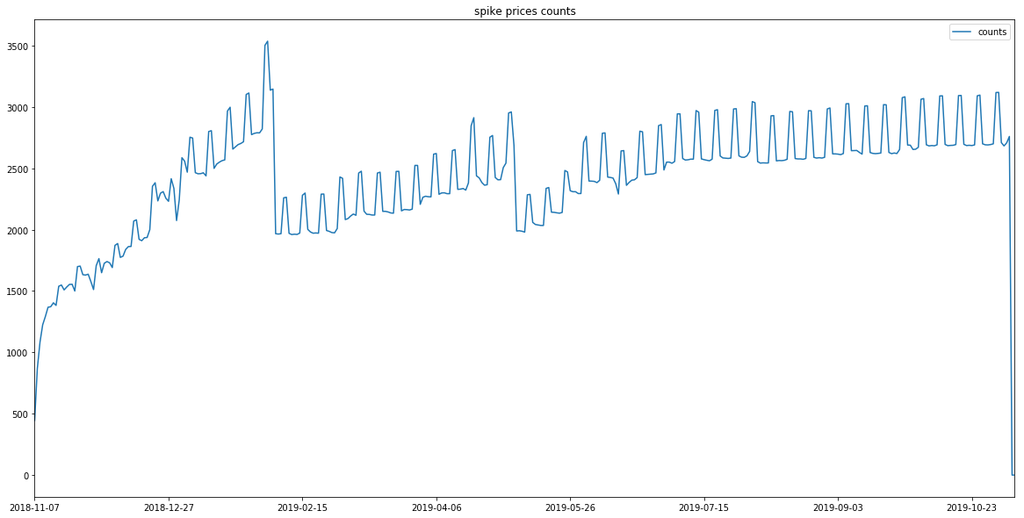

```python
fdate.plot(title='spike prices counts',y='counts',kind='line',figsize=(20,10))
plt.show()
```

### 这个图能说明什么？我觉得对于说明2月1号到2月2号是普遍的房源最高价应该是没问题的，接下啦统计这两天价格上涨的幅度。

```python
rows=[row for row in calendar_s_3.itertuples() if (getattr(row, 'date')=='2019-02-01')|(getattr(row, 'date')=='2019-02-02')]
new_calendar = pd.DataFrame(rows)
new_calendar.head()
```

|  | Index | listing_id | date | available | price |
| --- | --- | --- | --- | --- | --- |
| 0 | 299 | 3309 | 2019-02-02 | t | 30.0 |
| 1 | 300 | 3309 | 2019-02-01 | t | 30.0 |
| 2 | 783 | 16401 | 2019-02-02 | t | 120.0 |
| 3 | 784 | 16401 | 2019-02-01 | t | 120.0 |
| 4 | 1111 | 17409 | 2019-02-02 | t | 48.0 |

```python
new_calendar = new_calendar.drop(columns=['Index'])
new_calendar = new_calendar.reset_index(drop=True)#重置index
new_calendar['index'] = new_calendar.index#设置个index列后面有用
new_calendar['n_price'] = new_calendar['price']#后面有用
new_calendar.head()
```

|  | listing_id | date | available | price | index | n_price |
| --- | --- | --- | --- | --- | --- | --- |
| 0 | 3309 | 2019-02-02 | t | 30.0 | 0 | 30.0 |
| 1 | 3309 | 2019-02-01 | t | 30.0 | 1 | 30.0 |
| 2 | 16401 | 2019-02-02 | t | 120.0 | 2 | 120.0 |
| 3 | 16401 | 2019-02-01 | t | 120.0 | 3 | 120.0 |
| 4 | 17409 | 2019-02-02 | t | 48.0 | 4 | 48.0 |

#### 拷贝一份原来listing的数据，提取price部分

```python
listings_s_t = listings_s_1[['price']].copy()
listings_s_t['price'] = listings_s_t['price'].str.replace('$', '').str.replace(',', '').astype(float)
listings_s_t.head()
```

| id | price |
| --- | --- |
| 2015 | 60.0 |
| 2695 | 17.0 |
| 3176 | 90.0 |
| 3309 | 26.0 |
| 7071 | 42.0 |

### 接下来我打算把原来listings的price写入calendar的n_price里，为了这个我大费周折，因为遍历是很慢的，所以我之前只抽取了这两天的数据。原来是88万多行遍历改写十分之慢，现在只有7000多行。

```python
len(new_calendar)
```

```
7036
```

```python
# for i in range(0,len(calendar_s_3)-1):
#     print(i)
#     tin = calendar_s_3.loc[i,'listing_id']
#     calendar_s_3.loc[i,'n_price'] = listings_s_t.loc[tin,'price']
for row in new_calendar.itertuples(index=True, name='Pandas'):
    tin = getattr(row, 'listing_id')
    #print(getattr(row,'index'))
    new_calendar.loc[getattr(row,'index'),'n_price'] = listings_s_t.loc[tin,'price']
```

```python
new_calendar.head()
```

|  | listing_id | date | available | price | index | n_price |
| --- | --- | --- | --- | --- | --- | --- |
| 0 | 3309 | 2019-02-02 | t | 30.0 | 0 | 26.0 |
| 1 | 3309 | 2019-02-01 | t | 30.0 | 1 | 26.0 |
| 2 | 16401 | 2019-02-02 | t | 120.0 | 2 | 120.0 |
| 3 | 16401 | 2019-02-01 | t | 120.0 | 3 | 120.0 |
| 4 | 17409 | 2019-02-02 | t | 48.0 | 4 | 45.0 |

```python
new_calendar[new_calendar.n_price==0].index
```

```
Int64Index([4278, 4279], dtype='int64')
```

```python
new_calendar = new_calendar.drop(new_calendar[new_calendar.n_price == 0].index, axis=0)
```

```python
new_calendar[new_calendar.n_price==0].index
```

```
Int64Index([], dtype='int64')
```

```python
new_calendar['rate']=(new_calendar['price']-new_calendar['n_price'])/new_calendar['n_price']
new_calendar.head(20)
```

|  | listing_id | date | available | price | index | n_price | rate |
| --- | --- | --- | --- | --- | --- | --- | --- |
| 0 | 3309 | 2019-02-02 | t | 30.0 | 0 | 26.0 | 0.153846 |
| 1 | 3309 | 2019-02-01 | t | 30.0 | 1 | 26.0 | 0.153846 |
| 2 | 16401 | 2019-02-02 | t | 120.0 | 2 | 120.0 | 0.000000 |
| 3 | 16401 | 2019-02-01 | t | 120.0 | 3 | 120.0 | 0.000000 |
| 4 | 17409 | 2019-02-02 | t | 48.0 | 4 | 45.0 | 0.066667 |
| 5 | 17409 | 2019-02-01 | t | 48.0 | 5 | 45.0 | 0.066667 |
| 6 | 17904 | 2019-02-02 | t | 49.0 | 6 | 49.0 | 0.000000 |
| 7 | 17904 | 2019-02-01 | t | 49.0 | 7 | 49.0 | 0.000000 |
| 8 | 22677 | 2019-02-02 | t | 160.0 | 8 | 160.0 | 0.000000 |
| 9 | 22677 | 2019-02-01 | t | 160.0 | 9 | 160.0 | 0.000000 |
| 10 | 28711 | 2019-02-02 | t | 60.0 | 10 | 60.0 | 0.000000 |
| 11 | 28711 | 2019-02-01 | t | 60.0 | 11 | 60.0 | 0.000000 |
| 12 | 35642 | 2019-02-02 | t | 55.0 | 12 | 55.0 | 0.000000 |
| 13 | 35642 | 2019-02-01 | t | 55.0 | 13 | 55.0 | 0.000000 |
| 14 | 37836 | 2019-02-02 | t | 44.0 | 14 | 39.0 | 0.128205 |
| 15 | 37836 | 2019-02-01 | t | 44.0 | 15 | 39.0 | 0.128205 |
| 16 | 38296 | 2019-02-02 | t | 80.0 | 16 | 80.0 | 0.000000 |
| 17 | 38296 | 2019-02-01 | t | 80.0 | 17 | 80.0 | 0.000000 |
| 18 | 42809 | 2019-02-02 | t | 119.0 | 18 | 119.0 | 0.000000 |
| 19 | 42809 | 2019-02-01 | t | 119.0 | 19 | 119.0 | 0.000000 |

### 这两天的平均涨幅为：

```python
new_calendar['rate'].mean()
```

```
0.15829368932471388
```

### 但多数房源都没有涨（也就是说有很多房源的价格不随日期发生变化）

```python
new_calendar['rate'].median()
```

```
0.0
```

### 可见多数的房源都没有起伏，删去这些，并分为两个日期的

```python
c0201 = new_calendar.drop(new_calendar[ (new_calendar.rate == 0)|(new_calendar.date=='2019-02-02' )].index, axis=0)
c0201 = c0201.reset_index(drop=True)#重置index
c0201['index'] = c0201.index
c0202 = new_calendar.drop(new_calendar[ (new_calendar.rate == 0)|(new_calendar.date=='2019-02-01' )].index, axis=0)
c0202 = c0202.reset_index(drop=True)#重置index
c0202['index'] = c0202.index
```

### 分别求出两个日期排除不涨价的房源后，涨幅房源的平均上涨价格：

```python
c0201['rate'].mean()
```

```
0.48601518359840723
```

```python
c0202['rate'].mean()
```

```
0.4813665758637786
```

#### 再来看看reviews文件有什么用：

```python
n_r = reviews['date'].value_counts()[:100]
n_r[:20]
```

```
2017-05-28    1234
2018-05-21    1174
2018-09-30    1134
2018-09-16    1129
2018-09-02    1120
2018-05-13    1087
2018-09-10    1085
2018-09-17    1064
2018-10-14    1059
2018-09-23    1040
2018-09-09    1001
2018-10-07     982
2018-05-20     972
2018-08-26     971
2018-08-12     912
2018-10-21     901
2018-09-21     898
2018-04-02     891
2018-06-10     873
2018-06-03     872
Name: date, dtype: int64
```

```python
n_r = pd.DataFrame(n_r)
n_r = n_r.rename(columns={'date':'counts'})
n_r['date'] = n_r.index
n_r = n_r.sort_values('date')
n_r.head(10)
```

|  | counts | date |
| --- | --- | --- |
| 2017-01-02 | 591 | 2017-01-02 |
| 2017-04-17 | 689 | 2017-04-17 |
| 2017-05-01 | 602 | 2017-05-01 |
| 2017-05-28 | 1234 | 2017-05-28 |
| 2017-06-05 | 680 | 2017-06-05 |
| 2017-06-18 | 682 | 2017-06-18 |
| 2017-09-03 | 747 | 2017-09-03 |
| 2017-09-10 | 664 | 2017-09-10 |
| 2017-09-11 | 776 | 2017-09-11 |
| 2017-09-17 | 605 | 2017-09-17 |

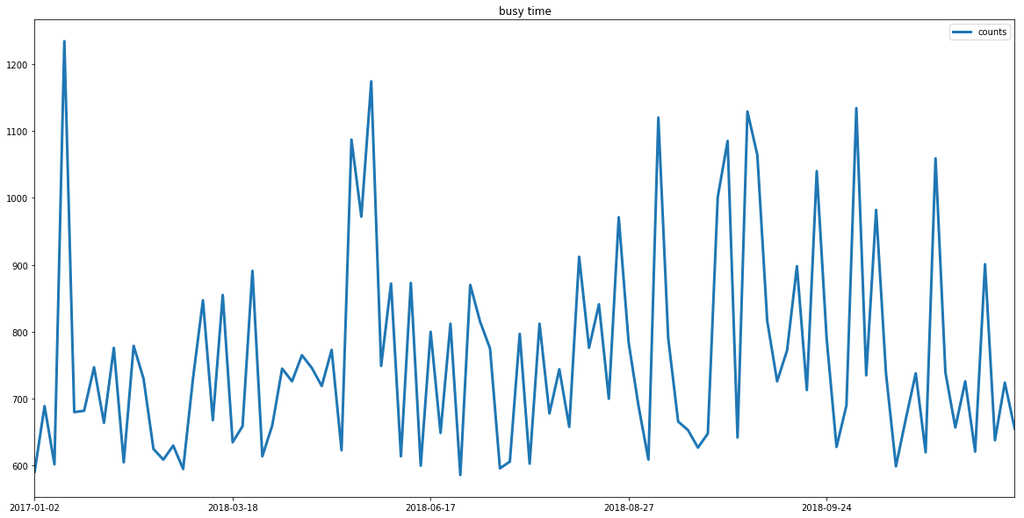

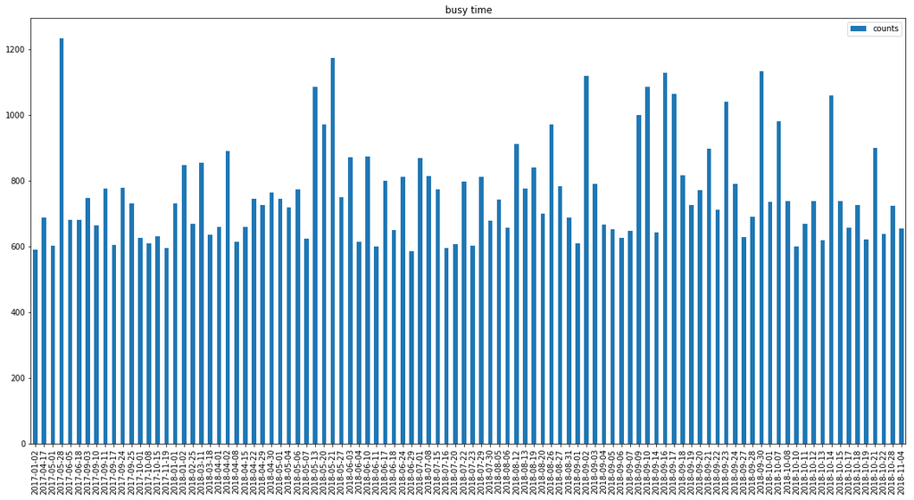

```python
n_r.plot(title='busy time',y='counts',kind='line',linewidth=3,figsize=(20,10))
plt.show()
n_r.plot(title='busy time',y='counts',kind='bar',linewidth=3,figsize=(20,10))
plt.show()
```

### 至于reviews能否代表Berlin住宿行业、旅游行业的访问率这是值得争议的，因为Airbnb只是众多民宿中的一种软件应用，其他非民宿酒店以及Airbnb本身随时间发展的数据变化，以上数据是复杂因素影响的结果。

### 另外，数据抓取时间对calendar的影响很大，所以上面我利用calendar做的分析也可能有很大问题。

### 这部分内容跟机器学习没什么关系，但对我的pandas函数调用考验很大。下面内容将抛开reviews和calendar，单单用listings_summary的各个特征来做预测price的机器学习模型。

# ONE-HOT编码

### 因为打算进行one-hot编码，查了很多资料，对于这种类别型的string，加州房价那种做法好像有些麻烦，换了种pandas自带的函数get_dummies https://pandas.pydata.org/pandas-docs/stable/reference/api/pandas.get_dummies.html 更方便。

### 把类型为string的列内容转换为category类型。

```python
for col in ['room_type', 'bed_type','host_has_profile_pic', 'instant_bookable', 'is_business_travel_ready', 'cancellation_policy']:
    listings_s_3[col] = listings_s_3[col].astype('category')
```

### 根据类型分为两组，并对category类型的进行转换

```python
num = listings_s_3.select_dtypes(include=['float64', 'int64', 'bool']).copy()
cat = listings_s_3.select_dtypes(include=['category']).copy()
cat_recoded = pd.get_dummies(cat)
cat_recoded
```

| id | room_type_Entire home/apt | room_type_Private room | room_type_Shared room | bed_type_Airbed | bed_type_Couch | bed_type_Futon | bed_type_Pull-out Sofa | bed_type_Real Bed | host_has_profile_pic_f | host_has_profile_pic_t | instant_bookable_f | instant_bookable_t | is_business_travel_ready_f | cancellation_policy_flexible | cancellation_policy_moderate | cancellation_policy_strict_14_with_grace_period | cancellation_policy_super_strict_30 | cancellation_policy_super_strict_60 |
| --- | --- | --- | --- | --- | --- | --- | --- | --- | --- | --- | --- | --- | --- | --- | --- | --- | --- | --- |
| 2015 | 1 | 0 | 0 | 0 | 0 | 0 | 0 | 1 | 0 | 1 | 1 | 0 | 1 | 0 | 0 | 1 | 0 | 0 |
| 2695 | 0 | 1 | 0 | 0 | 0 | 0 | 0 | 1 | 0 | 1 | 1 | 0 | 1 | 1 | 0 | 0 | 0 | 0 |
| 3176 | 1 | 0 | 0 | 0 | 0 | 0 | 0 | 1 | 0 | 1 | 0 | 1 | 1 | 0 | 0 | 1 | 0 | 0 |
| 3309 | 0 | 1 | 0 | 0 | 0 | 0 | 1 | 0 | 0 | 1 | 1 | 0 | 1 | 0 | 0 | 1 | 0 | 0 |
| 7071 | 0 | 1 | 0 | 0 | 0 | 0 | 0 | 1 | 0 | 1 | 1 | 0 | 1 | 0 | 1 | 0 | 0 | 0 |
| 9991 | 1 | 0 | 0 | 0 | 0 | 0 | 0 | 1 | 0 | 1 | 1 | 0 | 1 | 0 | 0 | 1 | 0 | 0 |
| 14325 | 1 | 0 | 0 | 0 | 0 | 0 | 0 | 1 | 0 | 1 | 1 | 0 | 1 | 0 | 0 | 1 | 0 | 0 |
| 16401 | 0 | 1 | 0 | 0 | 0 | 0 | 0 | 1 | 0 | 1 | 1 | 0 | 1 | 0 | 0 | 1 | 0 | 0 |
| 16644 | 1 | 0 | 0 | 0 | 0 | 0 | 0 | 1 | 0 | 1 | 1 | 0 | 1 | 0 | 0 | 1 | 0 | 0 |
| 17409 | 0 | 1 | 0 | 0 | 0 | 0 | 0 | 1 | 0 | 1 | 1 | 0 | 1 | 0 | 0 | 1 | 0 | 0 |
| 20858 | 1 | 0 | 0 | 0 | 0 | 0 | 0 | 1 | 0 | 1 | 1 | 0 | 1 | 0 | 0 | 1 | 0 | 0 |
| 21869 | 1 | 0 | 0 | 0 | 0 | 0 | 0 | 1 | 0 | 1 | 1 | 0 | 1 | 0 | 0 | 1 | 0 | 0 |
| 22415 | 1 | 0 | 0 | 0 | 0 | 0 | 0 | 1 | 0 | 1 | 1 | 0 | 1 | 0 | 0 | 1 | 0 | 0 |
| 22677 | 1 | 0 | 0 | 0 | 0 | 0 | 0 | 1 | 0 | 1 | 1 | 0 | 1 | 0 | 0 | 1 | 0 | 0 |
| 23834 | 1 | 0 | 0 | 0 | 0 | 0 | 0 | 1 | 0 | 1 | 1 | 0 | 1 | 0 | 0 | 1 | 0 | 0 |
| 24569 | 1 | 0 | 0 | 0 | 0 | 0 | 0 | 1 | 0 | 1 | 1 | 0 | 1 | 0 | 0 | 1 | 0 | 0 |
| 25653 | 1 | 0 | 0 | 0 | 0 | 0 | 0 | 1 | 0 | 1 | 1 | 0 | 1 | 0 | 0 | 1 | 0 | 0 |
| 26543 | 1 | 0 | 0 | 0 | 0 | 0 | 0 | 1 | 0 | 1 | 0 | 1 | 1 | 0 | 0 | 1 | 0 | 0 |
| 28156 | 1 | 0 | 0 | 0 | 0 | 0 | 0 | 1 | 0 | 1 | 1 | 0 | 1 | 0 | 0 | 1 | 0 | 0 |
| 28268 | 1 | 0 | 0 | 0 | 0 | 0 | 0 | 1 | 0 | 1 | 1 | 0 | 1 | 0 | 0 | 1 | 0 | 0 |
| 29279 | 1 | 0 | 0 | 0 | 0 | 0 | 0 | 1 | 0 | 1 | 1 | 0 | 1 | 0 | 0 | 1 | 0 | 0 |
| 30295 | 1 | 0 | 0 | 0 | 0 | 0 | 0 | 1 | 0 | 1 | 0 | 1 | 1 | 0 | 0 | 1 | 0 | 0 |
| 31440 | 0 | 1 | 0 | 0 | 0 | 0 | 0 | 1 | 0 | 1 | 1 | 0 | 1 | 0 | 1 | 0 | 0 | 0 |
| 33043 | 1 | 0 | 0 | 0 | 0 | 0 | 0 | 1 | 0 | 1 | 0 | 1 | 1 | 0 | 0 | 1 | 0 | 0 |
| 35642 | 1 | 0 | 0 | 0 | 0 | 0 | 0 | 1 | 0 | 1 | 0 | 1 | 1 | 0 | 0 | 1 | 0 | 0 |
| 36480 | 0 | 1 | 0 | 0 | 0 | 0 | 0 | 1 | 0 | 1 | 1 | 0 | 1 | 1 | 0 | 0 | 0 | 0 |
| 37004 | 0 | 1 | 0 | 0 | 0 | 0 | 0 | 1 | 0 | 1 | 1 | 0 | 1 | 0 | 0 | 1 | 0 | 0 |
| 37052 | 1 | 0 | 0 | 0 | 0 | 0 | 0 | 1 | 0 | 1 | 1 | 0 | 1 | 0 | 0 | 1 | 0 | 0 |
| 37836 | 0 | 1 | 0 | 0 | 0 | 0 | 0 | 1 | 0 | 1 | 1 | 0 | 1 | 0 | 1 | 0 | 0 | 0 |
| 38074 | 1 | 0 | 0 | 0 | 0 | 0 | 0 | 1 | 0 | 1 | 1 | 0 | 1 | 0 | 0 | 1 | 0 | 0 |
| ... | ... | ... | ... | ... | ... | ... | ... | ... | ... | ... | ... | ... | ... | ... | ... | ... | ... | ... |
| 29829280 | 0 | 1 | 0 | 0 | 0 | 0 | 0 | 1 | 0 | 1 | 0 | 1 | 1 | 1 | 0 | 0 | 0 | 0 |
| 29830140 | 0 | 1 | 0 | 0 | 0 | 0 | 0 | 1 | 0 | 1 | 0 | 1 | 1 | 0 | 1 | 0 | 0 | 0 |
| 29830204 | 1 | 0 | 0 | 0 | 0 | 0 | 0 | 1 | 0 | 1 | 1 | 0 | 1 | 0 | 0 | 1 | 0 | 0 |
| 29830381 | 0 | 1 | 0 | 0 | 0 | 0 | 0 | 1 | 0 | 1 | 1 | 0 | 1 | 0 | 0 | 1 | 0 | 0 |
| 29838765 | 1 | 0 | 0 | 0 | 0 | 0 | 0 | 1 | 0 | 1 | 1 | 0 | 1 | 1 | 0 | 0 | 0 | 0 |
| 29841234 | 0 | 1 | 0 | 0 | 0 | 0 | 0 | 1 | 0 | 1 | 1 | 0 | 1 | 0 | 0 | 1 | 0 | 0 |
| 29842909 | 1 | 0 | 0 | 0 | 0 | 0 | 0 | 1 | 0 | 1 | 1 | 0 | 1 | 1 | 0 | 0 | 0 | 0 |
| 29844866 | 0 | 1 | 0 | 0 | 0 | 0 | 0 | 1 | 0 | 1 | 1 | 0 | 1 | 1 | 0 | 0 | 0 | 0 |
| 29846605 | 1 | 0 | 0 | 0 | 0 | 0 | 0 | 1 | 0 | 1 | 1 | 0 | 1 | 1 | 0 | 0 | 0 | 0 |
| 29848269 | 1 | 0 | 0 | 0 | 0 | 0 | 0 | 1 | 0 | 1 | 1 | 0 | 1 | 0 | 0 | 1 | 0 | 0 |
| 29848527 | 1 | 0 | 0 | 0 | 0 | 0 | 0 | 1 | 0 | 1 | 1 | 0 | 1 | 0 | 0 | 1 | 0 | 0 |
| 29848903 | 1 | 0 | 0 | 0 | 0 | 0 | 0 | 1 | 0 | 1 | 1 | 0 | 1 | 1 | 0 | 0 | 0 | 0 |
| 29848907 | 0 | 1 | 0 | 0 | 0 | 0 | 0 | 1 | 0 | 1 | 1 | 0 | 1 | 0 | 0 | 1 | 0 | 0 |
| 29849186 | 0 | 1 | 0 | 0 | 0 | 0 | 0 | 1 | 0 | 1 | 1 | 0 | 1 | 0 | 0 | 1 | 0 | 0 |
| 29849565 | 1 | 0 | 0 | 0 | 0 | 0 | 0 | 1 | 0 | 1 | 0 | 1 | 1 | 1 | 0 | 0 | 0 | 0 |
| 29849958 | 0 | 1 | 0 | 0 | 0 | 0 | 0 | 1 | 0 | 1 | 1 | 0 | 1 | 0 | 0 | 1 | 0 | 0 |
| 29850404 | 0 | 1 | 0 | 0 | 0 | 0 | 0 | 1 | 0 | 1 | 0 | 1 | 1 | 1 | 0 | 0 | 0 | 0 |
| 29850644 | 1 | 0 | 0 | 0 | 0 | 0 | 0 | 1 | 0 | 1 | 1 | 0 | 1 | 1 | 0 | 0 | 0 | 0 |
| 29850727 | 1 | 0 | 0 | 0 | 0 | 0 | 0 | 1 | 0 | 1 | 1 | 0 | 1 | 1 | 0 | 0 | 0 | 0 |
| 29851223 | 0 | 1 | 0 | 0 | 0 | 0 | 0 | 1 | 0 | 1 | 0 | 1 | 1 | 1 | 0 | 0 | 0 | 0 |
| 29851651 | 0 | 1 | 0 | 0 | 0 | 0 | 0 | 1 | 0 | 1 | 0 | 1 | 1 | 1 | 0 | 0 | 0 | 0 |
| 29853463 | 0 | 0 | 1 | 0 | 0 | 0 | 0 | 1 | 0 | 1 | 1 | 0 | 1 | 1 | 0 | 0 | 0 | 0 |
| 29856029 | 1 | 0 | 0 | 0 | 0 | 0 | 0 | 1 | 0 | 1 | 0 | 1 | 1 | 1 | 0 | 0 | 0 | 0 |
| 29856359 | 0 | 1 | 0 | 0 | 0 | 0 | 0 | 1 | 0 | 1 | 0 | 1 | 1 | 0 | 1 | 0 | 0 | 0 |
| 29856646 | 1 | 0 | 0 | 0 | 0 | 0 | 0 | 1 | 0 | 1 | 0 | 1 | 1 | 0 | 0 | 1 | 0 | 0 |
| 29856708 | 1 | 0 | 0 | 0 | 0 | 0 | 0 | 1 | 0 | 1 | 1 | 0 | 1 | 1 | 0 | 0 | 0 | 0 |
| 29857108 | 0 | 0 | 1 | 0 | 0 | 0 | 0 | 1 | 0 | 1 | 0 | 1 | 1 | 1 | 0 | 0 | 0 | 0 |
| 29864272 | 1 | 0 | 0 | 0 | 0 | 0 | 0 | 1 | 0 | 1 | 1 | 0 | 1 | 1 | 0 | 0 | 0 | 0 |
| 29866805 | 0 | 1 | 0 | 0 | 0 | 0 | 0 | 1 | 0 | 1 | 1 | 0 | 1 | 1 | 0 | 0 | 0 | 0 |
| 29867352 | 0 | 1 | 0 | 0 | 0 | 0 | 0 | 1 | 0 | 1 | 1 | 0 | 1 | 1 | 0 | 0 | 0 | 0 |

22373 rows × 18 columns

### pd.concat用法参见http://pandas.pydata.org/pandas-docs/stable/reference/api/pandas.concat.html

*Combine DataFrame objects horizontally along the x axis by passing in axis=1. sort=true好像是新特性，原来是默认的，作用是确保index自动对应)

```python
listings_s_3_recoded = pd.concat([num, cat_recoded], axis=1)
listings_s_3_recoded.info()
```

```
<class 'pandas.core.frame.DataFrame'>
Int64Index: 22373 entries, 2015 to 29867352
Data columns (total 36 columns):
price                                              22373 non-null float64
accommodates                                       22373 non-null int64
bathrooms                                          22373 non-null float64
beds                                               22373 non-null float64
bedrooms                                           22373 non-null float64
cleaning_fee                                       22373 non-null float64
security_deposit                                   22373 non-null float64
extra_people                                       22373 non-null float64
guests_included                                    22373 non-null int64
Hair dryer                                         22373 non-null bool
Laptop_friendly_workspace                          22373 non-null bool
TV                                                 22373 non-null bool
Hot water                                          22373 non-null bool
Family/kid friendly                                22373 non-null bool
Internet                                           22373 non-null bool
Host greets you                                    22373 non-null bool
Smoking allowed                                    22373 non-null bool
distance                                           22373 non-null float64
room_type_Entire home/apt                          22373 non-null uint8
room_type_Private room                             22373 non-null uint8
room_type_Shared room                              22373 non-null uint8
bed_type_Airbed                                    22373 non-null uint8
bed_type_Couch                                     22373 non-null uint8
bed_type_Futon                                     22373 non-null uint8
bed_type_Pull-out Sofa                             22373 non-null uint8
bed_type_Real Bed                                  22373 non-null uint8
host_has_profile_pic_f                             22373 non-null uint8
host_has_profile_pic_t                             22373 non-null uint8
instant_bookable_f                                 22373 non-null uint8
instant_bookable_t                                 22373 non-null uint8
is_business_travel_ready_f                         22373 non-null uint8
cancellation_policy_flexible                       22373 non-null uint8
cancellation_policy_moderate                       22373 non-null uint8
cancellation_policy_strict_14_with_grace_period    22373 non-null uint8
cancellation_policy_super_strict_30                22373 non-null uint8
cancellation_policy_super_strict_60                22373 non-null uint8
dtypes: bool(8), float64(8), int64(2), uint8(18)
memory usage: 2.4 MB
```

## 划分训练集、测试集

```python
listings_s_4 = listings_s_3_recoded.copy()
from sklearn.model_selection import train_test_split
train_set,test_set=train_test_split(listings_s_4,test_size=0.2,random_state=42)
```

### 看看采样的测试集中可能是最大price影响因子的accommodates分布如何，可以对比发现数据集和测试集并没有太大区别，所以随机采样已经很好了，就不考虑分层采样了。

```python
test_set['accommodates'].value_counts()/len(test_set)
```

```
2     0.544581
4     0.140112
1     0.122905
3     0.112179
6     0.031061
5     0.030391
8     0.008268
7     0.005140
10    0.002011
9     0.001117
12    0.001117
11    0.000447
14    0.000447
15    0.000223
Name: accommodates, dtype: float64
```

```python
listings_s_4['accommodates'].value_counts()/len(listings_s_4)
```

```
2     0.542663
4     0.142493
1     0.121262
3     0.110759
6     0.032316
5     0.031243
8     0.006660
7     0.005721
10    0.002458
9     0.001520
12    0.001073
11    0.000670
16    0.000492
14    0.000358
15    0.000223
13    0.000089
Name: accommodates, dtype: float64
```

```python
trs_price = train_set["price"].copy()
trs_col = train_set.drop(columns=['price']).copy()
tes_price = test_set["price"].copy()
tes_col = test_set.drop(columns=['price']).copy()
```

# 选择模型

### 这里需要讨论一下，在加州房价的例子里，每一个尝试的模型都是用训练集做验证的，为了防止过拟合，用交叉验证进行评估。只有最后微调好决定的模型才在测试集上做验证。我个人的一个疑问是，最开始划分出的测试集的意义和交叉验证是否累赘了？我觉得可以在尝试阶段就两者都验证，毕竟这是一个“误差更小”和“过拟合”的博弈，这样更容易选出更适合的模型，这样就不需要交叉验证了。或者只采取交叉验证不需要额外的测试集。不过转念一想，留一个完全干净的测试集做二重验证，体现出了一种“流水线工程”的管理学意义，但可能没有太大提升性能的意义。

# 1. LinearRegression 线性回归

### 参数用法参见 https://scikit-learn.org/stable/modules/generated/sklearn.linear_model.LinearRegression.html

```python
lin_reg = LinearRegression(normalize=True)
lin_reg.fit(trs_col,trs_price)
```

```
LinearRegression(copy_X=True, fit_intercept=True, n_jobs=None, normalize=True)
```

### 选取训练集的前5个实例看一下预测情况：

```python
print("predictions:\t",lin_reg.predict(trs_col.iloc[:5]))
```

```
predictions:	 [174.5    62.     32.375  67.375  39.75 ]
```

```python
print("price:\t\t",list(trs_price.iloc[:5]))
```

```
price:		 [275.0, 35.0, 35.0, 45.0, 35.0]
```

### 看上去5个里面有两个误差还是比较大的，计算一下RMSE值，发现30对于绝大多数分布在0-100间的价格而言误差偏大。

```python
predictions = lin_reg.predict(trs_col)
lin_mse=mean_squared_error(trs_price,predictions)
lin_rmse=np.sqrt(lin_mse)
print(lin_rmse)
```

```
31.108978263622678
```

# 2.LogisticRegression 逻辑回归

```python
from sklearn.linear_model import LogisticRegression
log_reg = LogisticRegression(solver="liblinear", multi_class='auto',random_state=42)
log_reg.fit(trs_col,trs_price)
```

```
LogisticRegression(C=1.0, class_weight=None, dual=False, fit_intercept=True,
          intercept_scaling=1, max_iter=100, multi_class='auto',
          n_jobs=None, penalty='l2', random_state=42, solver='liblinear',
          tol=0.0001, verbose=0, warm_start=False)
```

```python
from sklearn.metrics import mean_squared_error
predictions = log_reg.predict(trs_col)
log_mse=mean_squared_error(trs_price,predictions)
log_rmse=np.sqrt(log_mse)
print(log_rmse)
```

```
35.653878002959296
```

### 效果没有线性回归好。

# 3. DecisionTreeRegressor 决策树

```python
from sklearn.tree import DecisionTreeRegressor
tree_reg = DecisionTreeRegressor()
tree_reg.fit(trs_col,trs_price)
```

```
DecisionTreeRegressor(criterion='mse', max_depth=None, max_features=None,
           max_leaf_nodes=None, min_impurity_decrease=0.0,
           min_impurity_split=None, min_samples_leaf=1,
           min_samples_split=2, min_weight_fraction_leaf=0.0,
           presort=False, random_state=None, splitter='best')
```

```python
predictions = tree_reg.predict(trs_col)
tree_mse=mean_squared_error(trs_price,predictions)
tree_rmse=np.sqrt(tree_mse)
tree_rmse
```

```
0.0
```

### 算法生成的决策树非常详细并且庞大，每个属性都被详细地加以考虑，决策树的树叶节点所覆盖的训练样本都是“纯”的。因此用这个决策树来对训练样本进行分类的话，很容易出现“过拟合”现象如上，即训练集的决策树完全把控了训练集的特征，误差为零。对比在测试集上的表现如下,确实是过拟合了。

```python
predictions = tree_reg.predict(tes_col)
tree_mse=mean_squared_error(tes_price,predictions)
tree_rmse=np.sqrt(tree_mse)
tree_rmse
```

```
40.587545217906964
```

## 交叉验证

> > 仿照加州房价我也用一下子交叉验证练练手。k折交叉验证（k=10）。可以发现交叉验证实际上就是在训练集上用若干种划分弄出测试集验证是否过拟合。

```python
def display_scores(scores):
    print("Scores:", scores)
    print("Mean:", scores.mean())
    print("Standard deviation:", scores.std())
```

```python
#线性回归
lin_scores=cross_val_score(lin_reg,trs_col,trs_price,scoring="neg_mean_squared_error",cv=10)
lin_rmse_scores=np.sqrt(-lin_scores)
display_scores(lin_rmse_scores)
#决策树
scores=cross_val_score(tree_reg,trs_col,trs_price,scoring="neg_mean_squared_error",cv=10)
tree_rmse_scores = np.sqrt(-scores)
display_scores(tree_rmse_scores)
```

```
Scores: [31.10130153 32.48332082 29.07686548 28.91207715 29.93427041 34.49307072
 30.97976002 32.23408349 32.01209748 30.46022868]
Mean: 31.16870757600134
Standard deviation: 1.617409567000289
Scores: [42.48318103 42.5298909  40.02086746 38.64744674 40.35577811 41.83557199
 42.08520222 42.84255312 44.71495961 42.14752897]
Mean: 41.76629801489649
Standard deviation: 1.6113686391536177
```

#### 确实是决策树比线性回归更差一些

# 4. RandomForestRegressor 随机森林

```python
from sklearn.ensemble import RandomForestRegressor

forest_reg=RandomForestRegressor(random_state=42)
forest_reg.fit(trs_col,trs_price)
```

```
c:\program files (x86)\microsoft visual studio\shared\python36_64\lib\site-packages\sklearn\ensemble\forest.py:246: FutureWarning: The default value of n_estimators will change from 10 in version 0.20 to 100 in 0.22.
  "10 in version 0.20 to 100 in 0.22.", FutureWarning)
```

```
RandomForestRegressor(bootstrap=True, criterion='mse', max_depth=None,
           max_features='auto', max_leaf_nodes=None,
           min_impurity_decrease=0.0, min_impurity_split=None,
           min_samples_leaf=1, min_samples_split=2,
           min_weight_fraction_leaf=0.0, n_estimators=10, n_jobs=None,
           oob_score=False, random_state=42, verbose=0, warm_start=False)
```

```python
predictions=forest_reg.predict(trs_col)
forest_mse=mean_squared_error(trs_price,predictions)
forest_rmse=np.sqrt(forest_mse)
forest_rmse
```

```
13.053820636519202
```

### 交叉验证：

```python
forest_scores=cross_val_score(forest_reg,trs_col,trs_price,scoring="neg_mean_squared_error",cv=10)
forest_rmse_scores=np.sqrt(-forest_scores)
display_scores(forest_rmse_scores)
```

```
Scores: [30.3508626  32.6057697  28.97802172 29.01755219 29.52675891 33.15737858
 31.76576035 31.01151912 31.34770018 30.55038531]
Mean: 30.831170866114963
Standard deviation: 1.3589566011871272
```

### 成绩比线性回归好一点点。尝试调整参数看看能不能提高：

## GridSearchCV 网络搜索

### 参见https://scikit-learn.org/stable/modules/generated/sklearn.model_selection.GridSearchCV.html 其中参数cv决定着交叉验证的折数。

### 在随机森林的参数中，bootstrap是个超参数可为true和false，param_grid的两部分分别对应着两种情况下的组合备选。因为参数维度过多后跑的时间比较久，我在多次试验后这里只写上几个确保快速跑完。

```python
param_grid = [{'n_estimators':[80,100],'max_features':[8,9]}]#这里本可以设置更多的待选参数，但是搜索时间实在过长，考虑到运行时间这里省略
          #  {'bootstrap':[False],'n_estimators':[80,100],'max_features':[8,9]},]

forest_reg = RandomForestRegressor()
grid_search = GridSearchCV(forest_reg,param_grid,cv=5,scoring='neg_mean_squared_error')
grid_search.fit(trs_col,trs_price)

cvres=grid_search.cv_results_
for mean_score,params in zip(cvres["mean_test_score"],cvres["params"]):
    print(np.sqrt(-mean_score),params)
print(grid_search.best_params_)
```

```
28.96171265359552 {'max_features': 8, 'n_estimators': 80}
28.870876938519107 {'max_features': 8, 'n_estimators': 100}
28.932078709747195 {'max_features': 9, 'n_estimators': 80}
28.82209060649065 {'max_features': 9, 'n_estimators': 100}
{'max_features': 9, 'n_estimators': 100}
```

```python
forest_reg=RandomForestRegressor(bootstrap= True,max_features=8, n_estimators=100, random_state=42)
forest_reg.fit(trs_col,trs_price)
predictions=forest_reg.predict(trs_col)
forest_mse=mean_squared_error(trs_price,predictions)
forest_rmse=np.sqrt(forest_mse)
forest_rmse
```

```
10.6459877274907
```

### 同理在测试集上跑这个参数下的模型，也只是28，不过也算是提高了一点性能。

```python
predictions=forest_reg.predict(tes_col)
forest_mse=mean_squared_error(tes_price,predictions)
forest_rmse=np.sqrt(forest_mse)
forest_rmse
```

```
28.34834203531943
```

## RandomizedSearchCV 随机搜索

### 再试一下随机搜索，参数含义参见https://scikit-learn.org/stable/modules/generated/sklearn.model_selection.RandomizedSearchCV.html， 和网络搜索相比，其中多了个n_iter参数，解释为：Number of parameter settings that are sampled. n_iter trades off runtime vs quality of the solution.控制着改变参数的搜索量。因为要跑很长时间，效果也不能明显提高，我这里全部注释掉了。

```python
# from sklearn.model_selection import RandomizedSearchCV
# from scipy.stats import randint

# param_distribs = {
#         'n_estimators': randint(low=1, high=200),
#         'max_features': randint(low=1, high=10),
#     }

# forest_reg = RandomForestRegressor(random_state=42)
# rnd_search = RandomizedSearchCV(forest_reg, param_distributions=param_distribs,
#                                 n_iter=20, cv=5, scoring='neg_mean_squared_error', random_state=42)
# rnd_search.fit(trs_col, trs_price)
```

```python
# cvres = rnd_search.cv_results_
# for mean_score, params in zip(cvres["mean_test_score"], cvres["params"]):
#     print(np.sqrt(-mean_score), params)
# print(rnd_search.best_params_)
```

```python
forest_reg = RandomForestRegressor(bootstrap= True, n_estimators=167, max_features=9,random_state=42)
forest_reg.fit(trs_col,trs_price)
forest_predictions_2 = forest_reg.predict(trs_col)
forest_mse = mean_squared_error(trs_price,forest_predictions_2)
forest_rmse = np.sqrt(forest_mse)
forest_rmse
```

```
10.593211318448894
```

```python
forest_predictions_2=forest_reg.predict(tes_col)
forest_mse=mean_squared_error(tes_price,forest_predictions_2)
forest_rmse=np.sqrt(forest_mse)
forest_rmse
```

```
28.273478649513997
```

# 5. SVR 支持向量机的线性回归模型

```python
from sklearn.svm import SVR #大概跑十几秒
svm_reg = SVR(kernel='poly', gamma='scale', C=1.0, epsilon=0.5)
svm_reg.fit(trs_col,trs_price)
```

```
SVR(C=1.0, cache_size=200, coef0=0.0, degree=3, epsilon=0.5, gamma='scale',
  kernel='poly', max_iter=-1, shrinking=True, tol=0.001, verbose=False)
```

```python
svm_predictions=svm_reg.predict(trs_col)
svm_mse=mean_squared_error(trs_price,svm_predictions)
svm_rmse=np.sqrt(svm_mse)
svm_rmse
```

```
43.47652583367061
```

### 我尝试了调整参数C=1,10,100,epsilon，0.1,0.5。发现最后的成绩都在42左右不是很理想。这个跑的很慢所以我用随机网络搜索最佳参数根本等不出结果（哭~）

```python
# param_distribs = {
#         'C': randint(low=0.5, high=100),
#         'epsilon': randint(low=0.1, high=1),
#     }
# svr_reg = SVR(kernel='poly', gamma='scale')
# svr_search = RandomizedSearchCV(svr_reg, param_distributions=param_distribs, n_iter=5, cv=5, scoring='neg_mean_squared_error', random_state=42)
# svr_search.fit(trs_col, trs_price)
```

# 6. XGBoost

> 调用参见 https://xgboost.readthedocs.io/en/latest/python/python_api.html

```python
#一分钟内
XGB_reg = xgb.XGBRegressor(max_depth=7, learning_rate=0.07, n_estimators=500, silent=False, objective='reg:gamma')
XGB_reg.fit(trs_col, trs_price)
XGB_predictions=XGB_reg.predict(trs_col)
XGB_mse=mean_squared_error(trs_price,XGB_predictions)
XGB_rmse=np.sqrt(XGB_mse)
XGB_rmse
```

```
c:\program files (x86)\microsoft visual studio\shared\python36_64\lib\site-packages\xgboost\core.py:587: FutureWarning: Series.base is deprecated and will be removed in a future version
  if getattr(data, 'base', None) is not None and \
```

```
18.914835733072433
```

### 交叉验证

```python
XGB_scores=cross_val_score(XGB_reg,trs_col,trs_price,scoring="neg_mean_squared_error",cv=4)
XGB_rmse_scores=np.sqrt(-XGB_scores)
display_scores(XGB_rmse_scores)
```

[output not shown]

```
Scores: [28.93677244 27.38851029 31.4789142  28.723928  ]
Mean: 29.132031231847535
Standard deviation: 1.4792226986600516
```

```python
XGB_predictions=XGB_reg.predict(tes_col)
XGB_mse=mean_squared_error(tes_price,XGB_predictions)
XGB_rmse=np.sqrt(XGB_mse)
XGB_rmse
```

```
28.612149884038757
```

# 7. GBRT梯度提升

```python
gbrt = GradientBoostingRegressor(max_depth=2, n_estimators=3, learning_rate=1.0)
gbrt.fit(trs_col, trs_price)
```

```
GradientBoostingRegressor(alpha=0.9, criterion='friedman_mse', init=None,
             learning_rate=1.0, loss='ls', max_depth=2, max_features=None,
             max_leaf_nodes=None, min_impurity_decrease=0.0,
             min_impurity_split=None, min_samples_leaf=1,
             min_samples_split=2, min_weight_fraction_leaf=0.0,
             n_estimators=3, n_iter_no_change=None, presort='auto',
             random_state=None, subsample=1.0, tol=0.0001,
             validation_fraction=0.1, verbose=0, warm_start=False)
```

```python
predictions=gbrt.predict(trs_col)
gbrt_mse=mean_squared_error(trs_price,predictions)
gbrt_rmse=np.sqrt(gbrt_mse)
gbrt_rmse
```

```
32.33617127871027
```

```python
predictions=gbrt.predict(tes_col)
gbrt_mse=mean_squared_error(tes_price,predictions)
gbrt_rmse=np.sqrt(gbrt_mse)
gbrt_rmse
```

```
32.149859918122196
```

# 改进模型

```python
feature_importances = grid_search.best_estimator_.feature_importances_
sorted(zip(feature_importances,trs_col),reverse=True)
```

```
[(0.1369505888020328, 'distance'),
 (0.12790814763463126, 'accommodates'),
 (0.10976687198336896, 'bedrooms'),
 (0.08432544040133601, 'cleaning_fee'),
 (0.07351245066215727, 'room_type_Entire home/apt'),
 (0.059753240208475444, 'bathrooms'),
 (0.05785183139500571, 'beds'),
 (0.05420146254927612, 'extra_people'),
 (0.04778321328324212, 'guests_included'),
 (0.039780316392646904, 'security_deposit'),
 (0.03602499166318742, 'room_type_Private room'),
 (0.016207774722951623, 'TV'),
 (0.01500296961549346, 'Family/kid friendly'),
 (0.0138162411838192, 'Laptop_friendly_workspace'),
 (0.013799539105126758, 'Internet'),
 (0.013204043394795681, 'Hot water'),
 (0.01305419418314906, 'Hair dryer'),
 (0.012295940006535331, 'Host greets you'),
 (0.011501405989034147, 'cancellation_policy_strict_14_with_grace_period'),
 (0.010354888852565887, 'instant_bookable_t'),
 (0.010234595468094965, 'instant_bookable_f'),
 (0.010186374401793853, 'cancellation_policy_flexible'),
 (0.009352432175602965, 'cancellation_policy_moderate'),
 (0.009237836092507641, 'Smoking allowed'),
 (0.003977446823353516, 'cancellation_policy_super_strict_30'),
 (0.0034814590617867035, 'cancellation_policy_super_strict_60'),
 (0.0029050466128102337, 'room_type_Shared room'),
 (0.0012807308609123164, 'bed_type_Real Bed'),
 (0.0010694662339396101, 'bed_type_Pull-out Sofa'),
 (0.0004330069171870365, 'bed_type_Futon'),
 (0.00028932003902543667, 'host_has_profile_pic_t'),
 (0.0002299949758714602, 'host_has_profile_pic_f'),
 (0.0001609419211156598, 'bed_type_Couch'),
 (6.579638716747564e-05, 'bed_type_Airbed'),
 (0.0, 'is_business_travel_ready_f')]
```

```python
listings_s_5 = listings_s_4.drop(columns=['bed_type_Airbed','bed_type_Couch','host_has_profile_pic_f','host_has_profile_pic_t','bed_type_Futon',])
from sklearn.model_selection import train_test_split
train_set,test_set=train_test_split(listings_s_5,test_size=0.2,random_state=42)
```

### 我觉得我做的误差还是太大了，考虑一定是之前的数据处理有哪些信息忽略了，我参考了另一个人的数据处理：https://www.kaggle.com/brittabettendorf/predicting-prices-xgboost-feature-engineering 发现我们的多数做法是一样的，但是她有个很突出的做法是分析了直接被我扔掉的description，并从中提取了一个属性size，成为了最影响XGBoost价格预测的那个属性。我想把她的做法借鉴过来用于随机森林试试能不能提高（从某种意义上可以说这部分算抄袭？）

### 她发现表示size的数字后总是跟着s,m之类关键字母

```python
listings_s_5['description'] = listings_summary.set_index('id')['description']
```

```python
listings_s_5['size'] = listings_s_5['description'].str.extract('(\d{2,3}\s?[smSM])', expand=True)
listings_s_5['size'] = listings_s_5['size'].str.replace("\D", "")

# change datatype of size into float
listings_s_5['size'] = listings_s_5['size'].astype(float)

print('NaNs in size_column absolute:     ', listings_s_5['size'].isna().sum())
print('NaNs in size_column in percentage:', round(listings_s_5['size'].isna().sum()/len(listings_s_5),3), '%')
```

```
NaNs in size_column absolute:      11709
NaNs in size_column in percentage: 0.523 %
```

```python
listings_s_5[['description', 'size']].head(10)
```

| id | description | size |
| --- | --- | --- |
| 2015 | Great location! 30 of 75 sq meters. This wood... | 75.0 |
| 2695 | In the summertime we are spending most of our ... | 25.0 |
| 3176 | This beautiful first floor apartment is situa... | 68.0 |
| 3309 | First of all: I prefer short-notice bookings. ... | 26.0 |
| 7071 | Cozy and large room in the beautiful district ... | 20.0 |
| 9991 | 4 bedroom with very large windows and outstand... | 780.0 |
| 14325 | The apartment is located on the upper second f... | NaN |
| 16401 | Hello future guests! We want to rent our cute ... | 55.0 |
| 16644 | Light and sunny 2-Room-turn of the century-fla... | 80.0 |
| 17409 | The 25 sqm room is located in the heart of Ber... | 25.0 |

```python
listings_s_5.drop(['description'], axis=1, inplace=True)
```

### 她又使用了一个技巧，用线性回归预测缺失的size

```python
sub_df = listings_s_5[['accommodates', 'bathrooms', 'bedrooms',  'price', 'cleaning_fee',
                 'security_deposit', 'extra_people', 'guests_included', 'distance', 'size']]
```

```python
train_data = sub_df[sub_df['size'].notnull()]
test_data  = sub_df[sub_df['size'].isnull()]
X_train = train_data.drop('size', axis=1)
X_test  = test_data.drop('size', axis=1)
y_train = train_data['size']
```

```python
print("Shape of Training Data:", train_data.shape)
print("Shape of Test Data:    ",test_data.shape)
print("\nShape of X_train:", X_train.shape)
print("Shape of X_test:", X_test.shape)
print("\nShape of y_train:", y_train.shape)
```

```
Shape of Training Data: (10664, 10)
Shape of Test Data:     (11709, 10)

Shape of X_train: (10664, 9)
Shape of X_test: (11709, 9)

Shape of y_train: (10664,)
```

```python
# instantiate
linreg = LinearRegression()

# fit model to training data
linreg.fit(X_train, y_train)
```

```
LinearRegression(copy_X=True, fit_intercept=True, n_jobs=None,
         normalize=False)
```

```python
y_test = linreg.predict(X_test)
y_test = pd.DataFrame(y_test)
y_test.columns = ['size']
print(y_test.shape)
y_test.head()
```

```
(11709, 1)
```

|  | size |
| --- | --- |
| 0 | 52.848091 |
| 1 | 94.788163 |
| 2 | 75.450352 |
| 3 | 87.455666 |
| 4 | 56.421890 |

### 这里把预测结果填入原来的表格还需要技巧，思路是把缺数据的dataframe的索引做成一个一维的属性为prelim的dataframe，注意这个dataframe的索引就变成了默认的01234，正好和训练出的y_test的索引保持了一致，就可以把两者拼起来了，然后在把prelim设置为索引,把这个dataframe和原来缺失size的x_test拼成不缺size的data，再和原来的不缺size的data拼到一起，就形成了不缺size的完整data。

```python
# make the index of X_test to an own dataframe
prelim_index = pd.DataFrame(X_test.index)
prelim_index.columns = ['prelim']

# ... and concat this dataframe with y_test
y_test = pd.concat([y_test, prelim_index], axis=1)
y_test.set_index(['prelim'], inplace=True)
y_test.head()
```

| prelim | size |
| --- | --- |
| 14325 | 52.848091 |
| 20858 | 94.788163 |
| 21869 | 75.450352 |
| 22415 | 87.455666 |
| 28156 | 56.421890 |

```python
new_test_data = pd.concat([X_test, y_test], axis=1)
print(new_test_data.shape)
new_test_data.head()
```

```
(11709, 10)
```

|  | accommodates | bathrooms | bedrooms | price | cleaning_fee | security_deposit | extra_people | guests_included | distance | size |
| --- | --- | --- | --- | --- | --- | --- | --- | --- | --- | --- |
| 14325 | 2 | 1.0 | 0.0 | 70.0 | 0.0 | 500.0 | 0.0 | 1 | 3.033091 | 52.848091 |
| 20858 | 4 | 1.0 | 2.0 | 129.0 | 49.0 | 500.0 | 24.0 | 2 | 1.821100 | 94.788163 |
| 21869 | 4 | 1.0 | 1.0 | 70.0 | 40.0 | 500.0 | 18.0 | 2 | 2.731728 | 75.450352 |
| 22415 | 4 | 1.0 | 2.0 | 98.0 | 50.0 | 300.0 | 25.0 | 2 | 3.213535 | 87.455666 |
| 28156 | 2 | 1.0 | 0.0 | 70.0 | 0.0 | 1660.0 | 0.0 | 1 | 2.908906 | 56.421890 |

```python
new_test_data['size'].isna().sum()
```

```
0
```

```python
# combine train and test data back to a new sub df
sub_df_new = pd.concat([new_test_data, train_data], axis=0)

print(sub_df_new.shape)
sub_df_new.head()
```

```
(22373, 10)
```

|  | accommodates | bathrooms | bedrooms | price | cleaning_fee | security_deposit | extra_people | guests_included | distance | size |
| --- | --- | --- | --- | --- | --- | --- | --- | --- | --- | --- |
| 14325 | 2 | 1.0 | 0.0 | 70.0 | 0.0 | 500.0 | 0.0 | 1 | 3.033091 | 52.848091 |
| 20858 | 4 | 1.0 | 2.0 | 129.0 | 49.0 | 500.0 | 24.0 | 2 | 1.821100 | 94.788163 |
| 21869 | 4 | 1.0 | 1.0 | 70.0 | 40.0 | 500.0 | 18.0 | 2 | 2.731728 | 75.450352 |
| 22415 | 4 | 1.0 | 2.0 | 98.0 | 50.0 | 300.0 | 25.0 | 2 | 3.213535 | 87.455666 |
| 28156 | 2 | 1.0 | 0.0 | 70.0 | 0.0 | 1660.0 | 0.0 | 1 | 2.908906 | 56.421890 |

```python
sub_df_new['size'].isna().sum()
```

```
0
```

```python
listings_s_5 = listings_s_5.drop(['accommodates', 'bathrooms', 'bedrooms', 'price', 'cleaning_fee',
             'security_deposit', 'extra_people', 'guests_included', 'distance', 'size'],
            axis=1, inplace=True)
listings_s_6 = pd.concat([sub_df_new, listings_s_5], axis=1)
print(listings_s_6.shape)
listings_s_6.head(2)
```

```
(22373, 10)
```

|  | accommodates | bathrooms | bedrooms | price | cleaning_fee | security_deposit | extra_people | guests_included | distance | size |
| --- | --- | --- | --- | --- | --- | --- | --- | --- | --- | --- |
| 14325 | 2 | 1.0 | 0.0 | 70.0 | 0.0 | 500.0 | 0.0 | 1 | 3.033091 | 52.848091 |
| 20858 | 4 | 1.0 | 2.0 | 129.0 | 49.0 | 500.0 | 24.0 | 2 | 1.821100 | 94.788163 |

```python
listings_s_6['size'].describe()
```

```
count    22373.000000
mean        59.751838
std         79.831865
min          0.000000
25%         25.000000
50%         49.248271
75%         64.788395
max        980.000000
Name: size, dtype: float64
```

```python
listings_s_6.drop(listings_s_6[ (listings_s_6['size'] == 0.) | (listings_s_6['size'] > 400.) ].index, axis=0, inplace=True)
```

### 再用这个做一遍随机森林

```python
train_set,test_set=train_test_split(listings_s_6,test_size=0.2,random_state=42)
trs_price = train_set["price"].copy()
trs_col = train_set.drop(columns=['price']).copy()
tes_price = test_set["price"].copy()
tes_col = test_set.drop(columns=['price']).copy()
```

```python
forest_reg=RandomForestRegressor(random_state=42)
forest_reg.fit(trs_col,trs_price)
predictions=forest_reg.predict(trs_col)
forest_mse=mean_squared_error(trs_price,predictions)
forest_rmse=np.sqrt(forest_mse)
forest_rmse
```

```
c:\program files (x86)\microsoft visual studio\shared\python36_64\lib\site-packages\sklearn\ensemble\forest.py:246: FutureWarning: The default value of n_estimators will change from 10 in version 0.20 to 100 in 0.22.
  "10 in version 0.20 to 100 in 0.22.", FutureWarning)
```

```
11.79327638406471
```

```python
predictions=forest_reg.predict(tes_col)
forest_mse=mean_squared_error(tes_price,predictions)
forest_rmse=np.sqrt(forest_mse)
forest_rmse
```

```
26.52560753372007
```

```python
param_grid = [{'n_estimators':[40,80,100],'max_features':[8,9]}]
grid_search = GridSearchCV(forest_reg,param_grid,cv=5,scoring='neg_mean_squared_error')
grid_search.fit(trs_col,trs_price)

cvres=grid_search.cv_results_
for mean_score,params in zip(cvres["mean_test_score"],cvres["params"]):
    print(np.sqrt(-mean_score),params)
print(grid_search.best_params_)
```

```
26.529178050692234 {'max_features': 8, 'n_estimators': 40}
26.418773061761012 {'max_features': 8, 'n_estimators': 80}
26.412436857061174 {'max_features': 8, 'n_estimators': 100}
26.67147392310688 {'max_features': 9, 'n_estimators': 40}
26.51534655508914 {'max_features': 9, 'n_estimators': 80}
26.470674226529322 {'max_features': 9, 'n_estimators': 100}
{'max_features': 8, 'n_estimators': 100}
```

```python
feature_importances = grid_search.best_estimator_.feature_importances_
sorted(zip(feature_importances,trs_col),reverse=True)
```

```
[(0.40035651281235496, 'size'),
 (0.1307542394996492, 'distance'),
 (0.12199263692439062, 'accommodates'),
 (0.1096717582036355, 'bedrooms'),
 (0.07839734750315658, 'cleaning_fee'),
 (0.06021189600719627, 'extra_people'),
 (0.035821364254523716, 'bathrooms'),
 (0.03338809440059438, 'security_deposit'),
 (0.029406150394498804, 'guests_included')]
```

### 可见size确实很重要，成绩也提高了一些。再试试这种处理下的XGBoost。

```python
XGB_reg = xgb.XGBRegressor(colsample_bytree=0.6,gamma=0.2,max_depth=7, learning_rate=0.05, n_estimators=500, silent=False, objective='reg:gamma')
XGB_reg.fit(trs_col, trs_price)
XGB_predictions=XGB_reg.predict(trs_col)
XGB_mse=mean_squared_error(trs_price,XGB_predictions)
XGB_rmse=np.sqrt(XGB_mse)
XGB_rmse
```

```
c:\program files (x86)\microsoft visual studio\shared\python36_64\lib\site-packages\xgboost\core.py:587: FutureWarning: Series.base is deprecated and will be removed in a future version
  if getattr(data, 'base', None) is not None and \
```

```
18.393850265761003
```

```python
XGB_scores=cross_val_score(XGB_reg,trs_col,trs_price,scoring="neg_mean_squared_error",cv=4)
XGB_rmse_scores=np.sqrt(-XGB_scores)
display_scores(XGB_rmse_scores)
```

[output not shown]

```
Scores: [25.01150817 27.40916497 27.44341475 25.12099331]
Mean: 26.2462703003755
Standard deviation: 1.1807163787410062
```

```python
XGB_predictions=XGB_reg.predict(tes_col)
XGB_mse=mean_squared_error(tes_price,XGB_predictions)
XGB_rmse=np.sqrt(XGB_mse)
XGB_rmse
```

```
24.33026030982041
```

```python
xg_train = xgb.DMatrix(data=trs_col, label=trs_price)
params = {'colsample_bytree':0.6, 'gamma':0.2, 'learning_rate':0.05, 'max_depth':6}
cv_results = xgb.cv(dtrain=xg_train, params=params, nfold=3,
                    num_boost_round=200, early_stopping_rounds=10,
                    metrics="rmse", as_pandas=True)
```

```
c:\program files (x86)\microsoft visual studio\shared\python36_64\lib\site-packages\xgboost\core.py:587: FutureWarning: Series.base is deprecated and will be removed in a future version
  if getattr(data, 'base', None) is not None and \
```

```python
cv_results.head()
```

|  | train-rmse-mean | train-rmse-std | test-rmse-mean | test-rmse-std |
| --- | --- | --- | --- | --- |
| 0 | 69.147924 | 0.548107 | 69.185577 | 1.099857 |
| 1 | 66.431099 | 0.520545 | 66.508347 | 1.111077 |
| 2 | 63.799768 | 0.531208 | 63.908644 | 1.076800 |
| 3 | 61.334986 | 0.504188 | 61.502591 | 1.078498 |
| 4 | 59.085534 | 0.579496 | 59.308057 | 0.987914 |

```python
cv_results.tail()
```

|  | train-rmse-mean | train-rmse-std | test-rmse-mean | test-rmse-std |
| --- | --- | --- | --- | --- |
| 195 | 19.789876 | 0.351995 | 26.647277 | 0.621809 |
| 196 | 19.769076 | 0.349780 | 26.643204 | 0.625173 |
| 197 | 19.750495 | 0.350239 | 26.642903 | 0.626814 |
| 198 | 19.733764 | 0.350102 | 26.643258 | 0.629227 |
| 199 | 19.717403 | 0.351914 | 26.643804 | 0.626426 |

# 用测试集评估系统

### 最后我用上面表现较好的随机森林作为最后的模型。虽然误差还是有点大，不过那个加州房价的预测也挺差的，可能这类预测确实比较困难。

```python
final_model = grid_search.best_estimator_
final_predictions = final_model.predict(tes_col)
final_mse = mean_squared_error(tes_price,final_predictions)
final_rmse=np.sqrt(final_mse)
final_rmse
```

```
24.95752413187257
```

计算测试的RMSE的95%的置信区间

```python
from scipy import stats
confidence=0.95
squared_errors = (final_predictions - tes_price) ** 2
mean = squared_errors.mean()
m = len(squared_errors)

np.sqrt(stats.t.interval(confidence, m - 1,loc=np.mean(squared_errors),scale=stats.sem(squared_errors)))
```

```
array([22.55116875, 27.15144213])
```

# 项目感想

### 1. 通过这次练习，连续几天挣扎在pandas的dataframe、series的添加、拼接、抽取、删除、转换的各种函数里，很多函数的复合往往达到很神奇效果，但很难想到，需要大量积累。

### 2. 数据处理的过程对后来模型误差影响很大，而其中最重要的就是提取特征，在这个项目里，我做的出色的地方就是从经纬度提取了一个“市中心距离”的概念，失误的地方在于，直接抛弃了string类型的description属性，看到他人的代码才意识到这里面还有可以提取的数字，后来也证明这里面的数字十分重要，误差也缩小了很多。

### 3. 机器学习的模型部分，原理我仅仅是清楚大概，只是会用，懂得模型的参数的含义，在应用方面已经足够了。但至于为什么这个模型会比另一个好，这样的问题我回答不出来。

### 4. 机器学习的各个部分都需要权衡，例如对于缺失数据，或者是偏离主体的数据，扔掉可以提高最后模型的准确率，但换个角度想，这也意味着可预测的范围减少了，那么这个度如何把握就需要权衡；另外，最典型的，训练集上很优秀的模型，不一定在测试集（交叉验证）优秀，如何权衡这两者间的误差也需要功夫。

### 5. 有一个不足的地方是我没有使用流水线pipeline，因为我深陷dataframe的数据处理，代码越来越长，使得不太好再去修改定义函数。